# Clusterização das Escolas Públicas Brasileiras para Análise de Grupos de Desempenho

### Carlos Eduardo Cassimiro da Silva Pedro Cercelino Matos

## 1. Problema

O Brasil continua sendo um dos países com maior desigualdade social do mundo, o que reflete que também existe desigualdade na educação, e consentemente no acesso à oportunidades possibilitadas pelo desenvolvimento do invíduo através de uma educação formal de qualidade [1]. O acesso a educação de qualidade contribui para diminuir a desigualdade social e melhorar a qualidade de vida da população, logo esforços para o desenvlvimento da educação no país tornam-se primordiais [2].  
Um das formas de analisar o desempenho da escolas é avaliar o seu Índice de Desenvolvimento da Educação Básica (Ideb), reúne, em um só indicador, os resultados de dois conceitos igualmente importantes para a qualidade da educação: o fluxo escolar e as médias de desempenho nas avaliações. O Ideb agrega ao enfoque pedagógico das avaliações em larga escala a possibilidade de resultados sintéticos, facilmente assimiláveis, e que permitem traçar metas de qualidade educacional para os sistemas [3].  
Assim, o presente trabalho buscará agrupar escolas a partir da idenficação de atributos similares, para avaliar se esses grupos refletem algum padrão de desempenho e características. Dessa maneira, com a separação de escolas por grupos, pode-se agilizar a análise, por profissionais da educação, na identificação das escolas, ou até mesmo de regiões, e suas características.

[1] https://brasilescola.uol.com.br/sociologia/desigualdade-social.htm  
[2] https://educacaointegral.org.br/reportagens/desigualdades-educacionais-no-brasil/  
[3] https://www.gov.br/inep/pt-br/areas-de-atuacao/pesquisas-estatisticas-e-indicadores/ideb

#### Conjunto de dados

Foram utilizados 3 conjuntos de dados para essa clusterização: o censo escolar de 2019, a notas do ideb de 2019 e um conjunto de dados auxiliar com os dados de geolocalização dos municipios brasileiros para visulizações em mapas.

• Censo Escolar 2019  
O Censo Escolar é o principal instrumento de coleta de informações da educação básica e a mais importante pesquisa estatística educacional brasileira. É coordenado pelo Inep e realizado em regime de colaboração entre as secretarias estaduais e municipais de educação e com a participação de todas as escolas públicas e privadas do país. A pesquisa estatística abrange as diferentes etapas e modalidades da educação básica e profissional. Entretanto, não utilizaremos os dados de escolas particulares, pois nem todas escolas particulares participam da prova do Saeb, e a porcentagem de participação é desconhecida, então desconsideramos por conta das incertezas.  
Link: https://www.gov.br/inep/pt-br/acesso-a-informacao/dados-abertos/microdados/censo-escolar

• Notas do Ideb 2019  
Como foi mensionado na introdução, o Ideb reúne, em um só indicador, os resultados de dois conceitos igualmente importantes para a qualidade da educação: o fluxo escolar e as médias de desempenho nas avaliações. O Ideb é calculado a partir dos dados sobre aprovação escolar, obtidos no Censo Escolar, e das médias de desempenho no Sistema de Avaliação da Educação Básica (Saeb). Para podermos generalizar a avaliação do ensino, utilizaremos somente a nota do Ideb, sem levar em consideração as notas do Saeb.  
Link: https://www.gov.br/inep/pt-br/areas-de-atuacao/pesquisas-estatisticas-e-indicadores/ideb/resultados

• Municipios Brasileiros  
Conjunto de dados auxiliar com os dados de geolocalização dos municipios brasileiros para visulizações em mapas.  
Link: https://github.com/kelvins/Municipios-Brasileiros

#### >>>Mudanças que aconteceram no projeto<<<

A principio, submetemos o trabalho como 'Clusterização das Escolas Públicas Brasileiras para Análise de Grupos de Desempenho', mas por não termos conseguido lidar com os tamanhos do arquivos de forma eficiente a tempo da entrega, tivemos que mudar o escopo de escolas públicas brasileiras para escolas públicas de ensino fundamental do Ceará, diminuindo o volume de dados e possibilitando a execução dos modelos em um tempo razoável para prosseguirmos com o trabalho. Dessa maneira, alguns passos e análises foram feitos primeiramente para o país inteira, mas que ainda assim fazem parte do pipeline para reduzirmos ao conjunto de dados referente ao Ceará

### Resumo da estratégia adotada

• Primeiramente, listamos os atributos mais importantes dos conjuntos, tanto para diminuir a dimensionalidade dos atributos e tentar ajudar os modelos quanto para diminuirmos um pouco o volume do dataset para processamento.

• Para diminuir ainda mais a dimensão dos atributos, aplicamos uma clusterização primeiramente em cada conjunto separadamente e em seguida aplicamos outra clusterização de disso. O objetivo da primeira clusterização é, além de reduzir o a dimensionalidade, tentar resumir as informações dos conjuntos de forma a distingui-los em grupos, preservando as diferenças. Também poderíamos passar a clusterização de dados categóricos e booleanos (natureza dos dados dos conjuntos) para dados numéricos a partir das contagens dos grupos, assim possibilitando utilizarmos mais modelos de clusterização, pois as gama de modelos para atributos de natureza categorica e booleana é menor. Além dos objetivos citados, também utilizamos essa estratégia para podemos lidar com os diferentes números de dados para cada escola, pois em uma escola há várias matrículas, várias turmas e docentes, dessa maneira poderíamos também resumir o número de linhas para somente uma, a linha da contagem dos clusters.

• Por exemplo, ao clusterizarmos os docentes de uma escola, poderíamos passar de 30 atributos categóricos e booleanos para 5 atributos (caso seja esse número de grupos), onde os valores desses atributos seria o número de docentes naquele cluster daquela referida escola. Essa lógica foi aplicada para cada conjunto de dados.

## 2. Pré-processamento

Embora os dados do Censo Escolar e Ideb sejam bem indexados e de fácil obtenção, o conjunto de dados é relativamente grande para ser aberto inteiramente em um computador sem algum outro recurso para manipulação de grandes dados, e existem dados faltantes por conta do não preenchimento completo do censo por algumas escolas, então precisamos fazer certos procedimentos para por trabalharmos com os dados.  
No caso do volume, para podermos utilizar o conjunto de dados sem usar algum recurso externo, podemos utilizar certos procedimentos na abertura do arquivo .csv. No caso dos dados faltantes, em alguns atributos podemos assumir certas condições e implicações, preenchendo-os por outros valores.

#### Bibliotecas utilizadas

```python
# É necessária a instalação no Kmodes para utilização no Colab
!pip install kmodes
```

```python
#Instalação necessária para a utilização dataframe dask no Colab
!python -m pip install dask[dataframe] --upgrade
```

```
     |████████████████████████████████| 118 kB 17.1 MB/s
```

```python
import pandas as pd
import zipfile
import numpy as np
import matplotlib.pyplot as plt
import dask.dataframe as dd
from yellowbrick.cluster import SilhouetteVisualizer
from kmodes.kmodes import KModes
from sklearn.cluster import KMeans
from sklearn.cluster import MiniBatchKMeans
from sklearn.metrics import silhouette_score
from sklearn.decomposition import PCA
from functools import reduce
```

```python
from google.colab import drive
drive.mount('/content/drive')
```

```python
#Estilização dos plots
plt.style.use("ggplot")
```

```python
#Caminho no drive para importações
general_path = "/content/drive/MyDrive/Colab Notebooks/"
```

### 2.1 Escolas

No conjunto de dados do censo, não utlizamos todos os dados os atributos, ao invés disso utilizamos somentes atributos selecionados que julgamos previamente, através de discussões, serem mais relevantes para caracterizar cada conjunto. A seleção previa foi necessária para podermos importarmos somente os atributos desejados, diminuindo espaço em memória na abertura conjunto.

```python
cols_esc = {'CO_ENTIDADE':'category',
            'CO_UF':'category',
            'TP_DEPENDENCIA':'category',
            'TP_LOCALIZACAO':'category',
            'TP_LOCALIZACAO_DIFERENCIADA':'category',
            'IN_VINCULO_SECRETARIA_EDUCACAO':'category',
            'IN_VINCULO_SEGURANCA_PUBLICA':'category',
            'TP_OCUPACAO_PREDIO_ESCOLAR':'category',
            'IN_LOCAL_FUNC_SOCIOEDUCATIVO':'category',
            'IN_LOCAL_FUNC_UNID_PRISIONAL':'category',
            'IN_LOCAL_FUNC_PRISIONAL_SOCIO':'category',
            'IN_LOCAL_FUNC_GALPAO':'category',
            'IN_ENERGIA_INEXISTENTE':'category',
            'IN_BIBLIOTECA':'category',
            'IN_LABORATORIO_CIENCIAS':'category',
            'IN_LABORATORIO_INFORMATICA':'category',
            'IN_ACESSIBILIDADE_INEXISTENTE':'category',
            'IN_EQUIP_MULTIMIDIA':'category',
            'IN_COMP_PORTATIL_ALUNO':'category',
            'IN_TABLET_ALUNO':'category',
            'IN_INTERNET':'category',
            'IN_MATERIAL_PED_CIENTIFICO':'category',
            'IN_EXAME_SELECAO':'category',
            'TP_PROPOSTA_PEDAGOGICA':'category'}
```

Para evitar a descompactação dos arquivos, utilizamos o ZipFile para extrairmos os dados diretos do arquivo .zip. Na instrução também já definimos os tipos dos atributos para categóricos, para diminuir o espaço ocupado do conjunto de dados. Em tipo categóricos, o pandas guarda os dados das categorias em memória, mas os dados subsequentes ele apenas salva um ponteiro para o valor da referida categoria, diminuindo assim o espaço ocupado em memória.

```python
with zipfile.ZipFile(general_path + 'microdados_educacao_basica_2019.zip') as z:
    with z.open('microdados_educacao_basica_2019/DADOS/ESCOLAS.CSV') as f:
        escolas = pd.read_csv(f,sep='|',
                              encoding='ISO-8859-1',
                              usecols=list(cols_esc.keys()),
                              dtype=cols_esc)
```

O arquivo original de escolas.CSV era de 111.3MB e conseguimos diminuir para 30.1MB como podemos ver ao final da instrução. Repetindo esse procedimento para todos os conjuntos, podemos diminuir drasticamente os 16GB totais do conjunto de dados.

```python
escolas.info(memory_usage="deep")
```

```
<class 'pandas.core.frame.DataFrame'>
RangeIndex: 228521 entries, 0 to 228520
Data columns (total 24 columns):
 #   Column                          Non-Null Count   Dtype
---  ------                          --------------   -----
 0   CO_ENTIDADE                     228521 non-null  category
 1   CO_UF                           228521 non-null  category
 2   TP_DEPENDENCIA                  228521 non-null  category
 3   TP_LOCALIZACAO                  228521 non-null  category
 4   TP_LOCALIZACAO_DIFERENCIADA     182468 non-null  category
 5   IN_VINCULO_SECRETARIA_EDUCACAO  140242 non-null  category
 6   IN_VINCULO_SEGURANCA_PUBLICA    140242 non-null  category
 7   TP_OCUPACAO_PREDIO_ESCOLAR      177167 non-null  category
 8   IN_LOCAL_FUNC_SOCIOEDUCATIVO    182468 non-null  category
 9   IN_LOCAL_FUNC_UNID_PRISIONAL    182468 non-null  category
```

[output cut: 16 more lines]

Com a instrução a baixo podemos ver que existem dados faltantes nesse conjunto. Então prosseguimos com o tratamentos desses casos.

```python
escolas.isna().sum()
```

```
CO_ENTIDADE                           0
CO_UF                                 0
TP_DEPENDENCIA                        0
TP_LOCALIZACAO                        0
TP_LOCALIZACAO_DIFERENCIADA       46053
IN_VINCULO_SECRETARIA_EDUCACAO    88279
IN_VINCULO_SEGURANCA_PUBLICA      88279
TP_OCUPACAO_PREDIO_ESCOLAR        51354
IN_LOCAL_FUNC_SOCIOEDUCATIVO      46053
IN_LOCAL_FUNC_UNID_PRISIONAL      46053
IN_LOCAL_FUNC_PRISIONAL_SOCIO     46053
IN_LOCAL_FUNC_GALPAO              46053
IN_ENERGIA_INEXISTENTE            46053
IN_BIBLIOTECA                     46053
IN_LABORATORIO_CIENCIAS           46053
IN_LABORATORIO_INFORMATICA        46053
IN_ACESSIBILIDADE_INEXISTENTE     46053
IN_EQUIP_MULTIMIDIA               46053
IN_COMP_PORTATIL_ALUNO            46053
IN_TABLET_ALUNO                   46053
IN_INTERNET                       46053
IN_MATERIAL_PED_CIENTIFICO        46053
IN_EXAME_SELECAO                  46053
TP_PROPOSTA_PEDAGOGICA            46053
dtype: int64
```

No caso de 'TP_OCUPACAO_PREDIO_ESCOLAR', que é uma variável categórica com 3 labels, avaliamos que os dados faltantes sejam para escolas que não ocupam prédio escolar, como indicado no dicionário de dados. Para não eliminarmos todas as linhas esses dados faltantes, adicionaremos uma categoria nova.

```python
escolas['TP_OCUPACAO_PREDIO_ESCOLAR'] = escolas['TP_OCUPACAO_PREDIO_ESCOLAR'].cat.add_categories(0)
```

Os atributos 'IN_VINCULO_SECRETARIA_EDUCACAO' e 'IN_VINCULO_SEGURANCA_PUBLICA' são booleanos, então assumimos que convém preenchermos os dados faltantes por 0, que significa que tais escolas não tem vínculo.

```python
escolas = escolas.fillna({'IN_VINCULO_SECRETARIA_EDUCACAO':'0',
                          'IN_VINCULO_SEGURANCA_PUBLICA':'0',
                          'TP_OCUPACAO_PREDIO_ESCOLAR':0})
```

Podemos ver que o resto dos dados faltantes sejam das mesmas linhas por terem todos os mesmo valores. Nessa caso, se elas todas não apresentam essas informações, não podemos preenche-las com outros valores.

```python
escolas.isna().sum()
```

```
CO_ENTIDADE                           0
CO_UF                                 0
TP_DEPENDENCIA                        0
TP_LOCALIZACAO                        0
TP_LOCALIZACAO_DIFERENCIADA       46053
IN_VINCULO_SECRETARIA_EDUCACAO        0
IN_VINCULO_SEGURANCA_PUBLICA          0
TP_OCUPACAO_PREDIO_ESCOLAR            0
IN_LOCAL_FUNC_SOCIOEDUCATIVO      46053
IN_LOCAL_FUNC_UNID_PRISIONAL      46053
IN_LOCAL_FUNC_PRISIONAL_SOCIO     46053
IN_LOCAL_FUNC_GALPAO              46053
IN_ENERGIA_INEXISTENTE            46053
IN_BIBLIOTECA                     46053
IN_LABORATORIO_CIENCIAS           46053
IN_LABORATORIO_INFORMATICA        46053
IN_ACESSIBILIDADE_INEXISTENTE     46053
IN_EQUIP_MULTIMIDIA               46053
IN_COMP_PORTATIL_ALUNO            46053
IN_TABLET_ALUNO                   46053
IN_INTERNET                       46053
IN_MATERIAL_PED_CIENTIFICO        46053
IN_EXAME_SELECAO                  46053
TP_PROPOSTA_PEDAGOGICA            46053
dtype: int64
```

```python
escolas = escolas.dropna()
```

### 2.2 Turmas

Os procedimentos são analógos para os outros conjuntos de dados. Em turmas, restaram poucos atributos relevantes pois nesse conjunto há muita repetição de atributos do conjunto de dados 'matrículas' e 'escolas'.

```python
cols_tur = {'CO_ENTIDADE':'category',
            'CO_UF':'category',
            'TP_MEDIACAO_DIDATICO_PEDAGO':'category',
            'NU_DIAS_ATIVIDADE':'category',
            'TP_TIPO_ATENDIMENTO_TURMA':'category'}

with zipfile.ZipFile(general_path + 'microdados_educacao_basica_2019.zip') as z:
    with z.open('microdados_educacao_basica_2019/DADOS/TURMAS.CSV') as f:
        turmas = pd.read_csv(f,sep='|',
                             encoding='ISO-8859-1',
                             usecols=list(cols_tur.keys()),
                             dtype=cols_tur)
```

```python
turmas.info()
```

```
<class 'pandas.core.frame.DataFrame'>
RangeIndex: 2432438 entries, 0 to 2432437
Data columns (total 5 columns):
 #   Column                       Dtype
---  ------                       -----
 0   TP_MEDIACAO_DIDATICO_PEDAGO  category
 1   NU_DIAS_ATIVIDADE            category
 2   TP_TIPO_ATENDIMENTO_TURMA    category
 3   CO_ENTIDADE                  category
 4   CO_UF                        category
dtypes: category(5)
memory usage: 25.0 MB
```

```python
turmas.isna().sum()
```

```
TP_MEDIACAO_DIDATICO_PEDAGO       0
NU_DIAS_ATIVIDADE              8591
TP_TIPO_ATENDIMENTO_TURMA         0
CO_ENTIDADE                       0
CO_UF                             0
dtype: int64
```

```python
turmas = turmas.dropna()
```

### 2.3 Matricula

```python
cols_mat = {"CO_ENTIDADE":'category',
            "CO_UF":'category',
            "TP_COR_RACA":'category',
            "TP_ZONA_RESIDENCIAL":'category',
            "TP_LOCAL_RESID_DIFERENCIADA":'category',
            "IN_NECESSIDADE_ESPECIAL":'category',
            "IN_TRANSPORTE_PUBLICO":'category',
            "IN_TRANSP_BICICLETA":'category',
            "IN_TRANSP_MICRO_ONIBUS":'category',
            "IN_TRANSP_ONIBUS":'category',
            "IN_TRANSP_TR_ANIMAL":'category',
            "IN_TRANSP_VANS_KOMBI":'category',
            "IN_TRANSP_OUTRO_VEICULO":'category'}
```

```python
with zipfile.ZipFile(general_path + 'microdados_educacao_basica_2019.zip') as z:
    with z.open('microdados_educacao_basica_2019/DADOS/MATRICULA_NORDESTE.CSV') as f:
        matriculas = pd.read_csv(f,sep='|',
                                 encoding='ISO-8859-1',
                                 usecols=list(cols_mat.keys()),
                                 dtype=cols_mat)
```

```python
matriculas.info(memory_usage="deep")
```

```
<class 'pandas.core.frame.DataFrame'>
RangeIndex: 15304589 entries, 0 to 15304588
Data columns (total 13 columns):
 #   Column                       Dtype
---  ------                       -----
 0   TP_COR_RACA                  category
 1   TP_ZONA_RESIDENCIAL          category
 2   TP_LOCAL_RESID_DIFERENCIADA  category
 3   IN_NECESSIDADE_ESPECIAL      category
 4   IN_TRANSPORTE_PUBLICO        category
 5   IN_TRANSP_BICICLETA          category
 6   IN_TRANSP_MICRO_ONIBUS       category
 7   IN_TRANSP_ONIBUS             category
 8   IN_TRANSP_TR_ANIMAL          category
 9   IN_TRANSP_VANS_KOMBI         category
 10  IN_TRANSP_OUTRO_VEICULO      category
 11  CO_ENTIDADE                  category
 12  CO_UF                        category
dtypes: category(13)
memory usage: 239.9 MB
```

```python
matriculas.isna().sum()
```

```
TP_COR_RACA                           0
TP_ZONA_RESIDENCIAL                  18
TP_LOCAL_RESID_DIFERENCIADA    10345300
IN_NECESSIDADE_ESPECIAL               0
IN_TRANSPORTE_PUBLICO             58792
IN_TRANSP_BICICLETA            12145386
IN_TRANSP_MICRO_ONIBUS         12145386
IN_TRANSP_ONIBUS               12145386
IN_TRANSP_TR_ANIMAL            12145386
IN_TRANSP_VANS_KOMBI           12145386
IN_TRANSP_OUTRO_VEICULO        12145386
CO_ENTIDADE                           0
CO_UF                                 0
dtype: int64
```

```python
matriculas = matriculas.fillna({'TP_LOCAL_RESID_DIFERENCIADA':'0',
                                'IN_TRANSPORTE_PUBLICO':'0',
                                'IN_TRANSP_BICICLETA':'0',
                                'IN_TRANSP_MICRO_ONIBUS':'0',
                                'IN_TRANSP_ONIBUS':'0',
                                'IN_TRANSP_TR_ANIMAL':'0',
                                'IN_TRANSP_VANS_KOMBI':'0',
                                'IN_TRANSP_OUTRO_VEICULO':'0'})
```

```python
matriculas.isna().sum()
```

```
TP_COR_RACA                     0
TP_ZONA_RESIDENCIAL            18
TP_LOCAL_RESID_DIFERENCIADA     0
IN_NECESSIDADE_ESPECIAL         0
IN_TRANSPORTE_PUBLICO           0
IN_TRANSP_BICICLETA             0
IN_TRANSP_MICRO_ONIBUS          0
IN_TRANSP_ONIBUS                0
IN_TRANSP_TR_ANIMAL             0
IN_TRANSP_VANS_KOMBI            0
IN_TRANSP_OUTRO_VEICULO         0
CO_ENTIDADE                     0
CO_UF                           0
dtype: int64
```

```python
matriculas.dropna(inplace=True)
```

### 2.4 Docentes

```python
cols_doc = {"CO_ENTIDADE":'category',
            "CO_UF":'category',
           	"TP_ESCOLARIDADE":'category',
           	"TP_TIPO_IES_1":'category',
           	"IN_COMPLEMENTACAO_PEDAGOGICA":'category',
           	"IN_ESPECIALIZACAO":'category',
           	"IN_MESTRADO":'category',
           	"IN_DOUTORADO":'category',
           	"IN_POS_NENHUM":'category'}

with zipfile.ZipFile(general_path + 'microdados_educacao_basica_2019.zip') as z:
        with z.open('microdados_educacao_basica_2019/DADOS/DOCENTES_NORDESTE.CSV') as f:
            docentes = pd.read_csv(f,sep='|',
                                   encoding='ISO-8859-1',
                                   usecols=list(cols_doc.keys()),
                                   dtype = cols_doc)
```

```python
docentes.info()
```

```
<class 'pandas.core.frame.DataFrame'>
RangeIndex: 3044057 entries, 0 to 3044056
Data columns (total 9 columns):
 #   Column                        Dtype
---  ------                        -----
 0   TP_ESCOLARIDADE               category
 1   TP_TIPO_IES_1                 category
 2   IN_COMPLEMENTACAO_PEDAGOGICA  category
 3   IN_ESPECIALIZACAO             category
 4   IN_MESTRADO                   category
 5   IN_DOUTORADO                  category
 6   IN_POS_NENHUM                 category
 7   CO_ENTIDADE                   category
 8   CO_UF                         category
dtypes: category(9)
memory usage: 37.8 MB
```

```python
docentes.isna().sum()
```

```
TP_ESCOLARIDADE                       0
TP_TIPO_IES_1                   1042540
IN_COMPLEMENTACAO_PEDAGOGICA          0
IN_ESPECIALIZACAO                558340
IN_MESTRADO                      558340
IN_DOUTORADO                     558340
IN_POS_NENHUM                    558340
CO_ENTIDADE                           0
CO_UF                                 0
dtype: int64
```

```python
docentes = docentes.fillna({'TP_TIPO_IES_1':'2',
                            'IN_ESPECIALIZACAO':'0',
                            'IN_MESTRADO':'0',
                            'IN_DOUTORADO':'0',
                            'IN_POS_NENHUM':'0'
                           })
```

```python
docentes.isna().sum()
```

```
TP_ESCOLARIDADE                 0
TP_TIPO_IES_1                   0
IN_COMPLEMENTACAO_PEDAGOGICA    0
IN_ESPECIALIZACAO               0
IN_MESTRADO                     0
IN_DOUTORADO                    0
IN_POS_NENHUM                   0
CO_ENTIDADE                     0
CO_UF                           0
dtype: int64
```

### 2.5 Notas do Ideb e geolocalização do municípios

#### 2.5.1 Ideb por município

Como podemos ver, existem alguns dados faltantes nas notas do Ideb. Para a análise explorátória, estaremos utilizando os dados do Ideb por municipio. As notas são separadas pela rede estadual, municipal, federal e pública, mas nem todos os muncípios possuem todas as redes, mas ainda assim o espaço fica na tabela, gerando dados faltantes. Nesse caso, podemos elimina-las. Os dados do Ideb por muncípio serão utilizados para visualização da dispersão das notas no mapa do Brasil.

```python
ideb = pd.read_csv(general_path + 'ideb_2019.csv', sep=';', na_values='-')
ideb.isna().sum()
```

```
UF               0
COD_MUNIC        0
NOME_MUNIC       0
REDE             0
NOTA_IDEB     2278
dtype: int64
```

```python
ideb = ideb.dropna()
ideb.head()
```

|  | UF | COD_MUNIC | NOME_MUNIC | REDE | NOTA_IDEB |
| --- | --- | --- | --- | --- | --- |
| 0 | RO | 1100015 | Alta Floresta D'Oeste | Estadual | 5,8 |
| 1 | RO | 1100015 | Alta Floresta D'Oeste | Municipal | 4,7 |
| 2 | RO | 1100015 | Alta Floresta D'Oeste | Pública | 5,7 |
| 3 | RO | 1100023 | Ariquemes | Estadual | 5,3 |
| 4 | RO | 1100023 | Ariquemes | Municipal | 5,1 |

Como dito anteriormente, as notas são separadas pela rede estadual, municipal, federal e pública, não encontramos explicação de como é feito o cálculo da rede pública no geral, mas é ela que sempre é referenciada em análises encontradas na internet, então selecionaremos somente as notas da rede pública.

```python
cod_notas = ideb.filter(items=['UF','COD_MUNIC','NOTA_IDEB']).where(ideb.REDE=='Pública')
cod_notas = cod_notas.dropna()
```

#### 2.5.2 Municipios

```python
municipios = pd.read_csv(general_path + 'municipios.csv', usecols=['codigo_ibge','latitude','longitude'])
```

```python
municipios.head()
```

|  | codigo_ibge | latitude | longitude |
| --- | --- | --- | --- |
| 0 | 5200050 | -16.75730 | -49.4412 |
| 1 | 3100104 | -18.48310 | -47.3916 |
| 2 | 5200100 | -16.19700 | -48.7057 |
| 3 | 3100203 | -19.15510 | -45.4444 |
| 4 | 1500107 | -1.72183 | -48.8788 |

Para a plotarmos os gráficos de dispersão das notas e visualizá-los dispersos no mapa do Brasil, podemos utilizar as coordenadas de longitude e latitude como x e y de um plot comum. Para isso, precisamos juntar as notas do referidos municipios e as suas coordenadas.

```python
ideb_municipios = pd.merge(municipios,cod_notas,
                           how='left', left_on=['codigo_ibge'],
                           right_on=['COD_MUNIC'])
```

Ajustando a formatação dos dados para converoa para float.

```python
ideb_municipios['NOTA_IDEB'] = ideb_municipios['NOTA_IDEB'].str.replace(',','.')
ideb_municipios['NOTA_IDEB'] = ideb_municipios['NOTA_IDEB'].astype('float')
```

### 2.6 Seleção dos dados do Ceará

#### 2.6.1 Notas do Ceará por município e por escola

Para selecionar as escolas do estado do Ceará, utilizaremos o atributo 'CO_UF' (Código de Unidade Federativa) igual a 23, que corresponde ao Ceará.

```python
escolas_ce = escolas[escolas['CO_UF']=='23']
escolas_ce.info()
```

```
<class 'pandas.core.frame.DataFrame'>
Int64Index: 7608 entries, 60621 to 87931
Data columns (total 24 columns):
 #   Column                          Non-Null Count  Dtype
---  ------                          --------------  -----
 0   CO_ENTIDADE                     7608 non-null   category
 1   CO_UF                           7608 non-null   category
 2   TP_DEPENDENCIA                  7608 non-null   category
 3   TP_LOCALIZACAO                  7608 non-null   category
 4   TP_LOCALIZACAO_DIFERENCIADA     7608 non-null   category
 5   IN_VINCULO_SECRETARIA_EDUCACAO  7608 non-null   category
 6   IN_VINCULO_SEGURANCA_PUBLICA    7608 non-null   category
 7   TP_OCUPACAO_PREDIO_ESCOLAR      7608 non-null   category
 8   IN_LOCAL_FUNC_SOCIOEDUCATIVO    7608 non-null   category
 9   IN_LOCAL_FUNC_UNID_PRISIONAL    7608 non-null   category
```

[output cut: 16 more lines]

#### 2.6.2 Turmas do Ceará

```python
turmas_ce = turmas[turmas.CO_ENTIDADE.isin(escolas_ce['CO_ENTIDADE'])]
turmas_ce.info()
```

```
<class 'pandas.core.frame.DataFrame'>
Int64Index: 112918 entries, 62 to 2432349
Data columns (total 5 columns):
 #   Column                       Non-Null Count   Dtype
---  ------                       --------------   -----
 0   TP_MEDIACAO_DIDATICO_PEDAGO  112918 non-null  category
 1   NU_DIAS_ATIVIDADE            112918 non-null  category
 2   TP_TIPO_ATENDIMENTO_TURMA    112918 non-null  category
 3   CO_ENTIDADE                  112918 non-null  category
 4   CO_UF                        112918 non-null  category
dtypes: category(5)
memory usage: 8.1 MB
```

#### 2.6.3 Matrículas do Ceará

```python
matriculas_ce = matriculas[matriculas.CO_ENTIDADE.isin(escolas_ce['CO_ENTIDADE'])]
matriculas_ce.info()
```

```
<class 'pandas.core.frame.DataFrame'>
Int64Index: 2522937 entries, 3925790 to 6448727
Data columns (total 13 columns):
 #   Column                       Dtype
---  ------                       -----
 0   TP_COR_RACA                  category
 1   TP_ZONA_RESIDENCIAL          category
 2   TP_LOCAL_RESID_DIFERENCIADA  category
 3   IN_NECESSIDADE_ESPECIAL      category
 4   IN_TRANSPORTE_PUBLICO        category
 5   IN_TRANSP_BICICLETA          category
 6   IN_TRANSP_MICRO_ONIBUS       category
 7   IN_TRANSP_ONIBUS             category
 8   IN_TRANSP_TR_ANIMAL          category
 9   IN_TRANSP_VANS_KOMBI         category
 10  IN_TRANSP_OUTRO_VEICULO      category
 11  CO_ENTIDADE                  category
 12  CO_UF                        category
dtypes: category(13)
memory usage: 60.7 MB
```

#### 2.6.4 Docentes do Ceará

```python
docentes_ce = docentes[docentes.CO_ENTIDADE.isin(escolas_ce['CO_ENTIDADE'])]
docentes_ce.info()
```

```
<class 'pandas.core.frame.DataFrame'>
Int64Index: 493212 entries, 13 to 3043953
Data columns (total 9 columns):
 #   Column                        Non-Null Count   Dtype
---  ------                        --------------   -----
 0   TP_ESCOLARIDADE               493212 non-null  category
 1   TP_TIPO_IES_1                 493212 non-null  category
 2   IN_COMPLEMENTACAO_PEDAGOGICA  493212 non-null  category
 3   IN_ESPECIALIZACAO             493212 non-null  category
 4   IN_MESTRADO                   493212 non-null  category
 5   IN_DOUTORADO                  493212 non-null  category
 6   IN_POS_NENHUM                 493212 non-null  category
 7   CO_ENTIDADE                   493212 non-null  category
 8   CO_UF                         493212 non-null  category
dtypes: category(9)
memory usage: 12.4 MB
```

### 2.7 Filtrando os conjuntos de dados para as escolas com as notas do ideb disponíveis

Primeiro filtramos os dados do Ceará para podemos diminuir o número de iterações do segundo filtro. O segundo filtro consiste em pegar somente as escolas com as notas do Ideb disponíveis, pois não temos as notas de escolas que são exclusivamente EJA ou profissionalizantes, então as retiramos para não inviésarmos os agrupamentos.  
Os dados são divididos em anos iniciais (1º ao 5º) e finais (6º ao 9°), então vamos juntar os conjuntos de dados. Para escolas do ensino fundamental que são somente de ano iniciais ou finais, mantemos somentes os valores incidentes. No caso de escolas com as duas modalidades, fizemos uma média.

```python
finais = pd.read_csv(general_path + "ideb_2019_ escolas_anos_finais", sep=';', na_values='-')
iniciais = pd.read_csv(general_path + "ideb_2019_ escolas_anos_iniciais", sep=';', na_values='-')
```

Primeiro, retiramos os dados faltantes e selecionamos somente os dados do Ceará.

```python
finais = finais.dropna()
iniciais = iniciais.dropna()

finais = finais[finais['UF']=='CE']
iniciais = iniciais[iniciais['UF']=='CE']
```

Em seguida, substituímos as vírgulas por pontos para poder transformar os dados em float.

```python
finais['NOTA_IDEB'] = finais['NOTA_IDEB'].str.replace(',','.').astype('float')
iniciais['NOTA_IDEB'] = iniciais['NOTA_IDEB'].str.replace(',','.').astype('float')
```

Juntando os dados a partir do código da escola.

```python
IDEB_geral = iniciais.merge(finais,
                            how='outer',
                            on='COD_ESCOLA',
                            indicator='flag', suffixes=['_AF', '_AI'])
```

Aqui, juntamos os dois conjuntos de dados aplicando as regras ditas à cima.

```python
nota = []
for i in IDEB_geral.index:
    if(IDEB_geral['flag'][i] == 'both'):
        nota.append((IDEB_geral['NOTA_IDEB_AF'][i]+IDEB_geral['NOTA_IDEB_AI'][i])/2)
    elif(IDEB_geral['flag'][i] == 'left_only'):
        nota.append(IDEB_geral['NOTA_IDEB_AF'][i])
    else:
        nota.append(IDEB_geral['NOTA_IDEB_AI'][i])
```

```python
IDEB_geral['NOTA_IDEB'] = nota
IDEB_geral = IDEB_geral.drop(['NOTA_IDEB_AI','NOTA_IDEB_AF','flag','UF_AF','UF_AI'], axis=1)
```

### 2.8 Seleção dos dados filtrados pelas escolas cearense com notas disponíveis no Ideb

Nem todas as escolas públicas realizaram a prova do SAEB ou forneceram os dados necessários para o cálculo do Ideb de 2019, por isso, selecionaremos somentes as escolas cearences que possuem essa nota, a partir do seu código de escola que as identifica.

#### 2.8.1 Escolas

A coluna do código de escolas do conjunto de escolas com notas do Ideb é inteiro, então precisamos converter a coluna do código do conjunto de escolas do censo escolas para inteiro também.

```python
escolas_ce['CO_ENTIDADE'] = escolas_ce['CO_ENTIDADE'].astype('int')
```

Em seguida, filtramos somente as escolas do censo que possuiem nota no Ideb.

```python
escolas_ce_Ideb = escolas_ce.merge(IDEB_geral, how = 'inner', left_on='CO_ENTIDADE', right_on='COD_ESCOLA')
escolas_ce_Ideb.drop(columns=['NOTA_IDEB', 'CO_UF', 'COD_ESCOLA', 'CO_ENTIDADE'], inplace=True)
escolas_ce_Ideb.info()
```

[output not shown]

#### 2.8.2 Turmas

Repetimos o mesmo prosseno nos outros conjuntos.

```python
turmas_ce['CO_ENTIDADE'] = turmas_ce['CO_ENTIDADE'].astype('int')
```

```python
turmas_ce_Ideb = turmas_ce.merge(IDEB_geral, how = 'inner', left_on='CO_ENTIDADE', right_on='COD_ESCOLA')
turmas_ce_Ideb.drop(columns=['NOTA_IDEB', 'CO_UF', 'COD_ESCOLA', 'CO_ENTIDADE'], inplace=True)
```

```python
turmas_ce_Ideb.info()
```

```
<class 'pandas.core.frame.DataFrame'>
Int64Index: 63027 entries, 0 to 63026
Data columns (total 3 columns):
 #   Column                       Non-Null Count  Dtype
---  ------                       --------------  -----
 0   TP_MEDIACAO_DIDATICO_PEDAGO  63027 non-null  category
 1   NU_DIAS_ATIVIDADE            63027 non-null  category
 2   TP_TIPO_ATENDIMENTO_TURMA    63027 non-null  category
dtypes: category(3)
memory usage: 677.7 KB
```

#### 2.8.3 Matrículas

```python
matriculas_ce['CO_ENTIDADE'] = matriculas_ce['CO_ENTIDADE'].astype('int')
```

```python
matriculas_ce_Ideb = matriculas_ce.merge(IDEB_geral, how = 'inner', left_on='CO_ENTIDADE', right_on='COD_ESCOLA')
matriculas_ce_Ideb.drop(columns=['NOTA_IDEB', 'CO_UF', 'COD_ESCOLA', 'CO_ENTIDADE'], inplace=True)
matriculas_ce_Ideb.info()
```

```
<class 'pandas.core.frame.DataFrame'>
Int64Index: 1405544 entries, 0 to 1405543
Data columns (total 11 columns):
 #   Column                       Non-Null Count    Dtype
---  ------                       --------------    -----
 0   TP_COR_RACA                  1405544 non-null  category
 1   TP_ZONA_RESIDENCIAL          1405544 non-null  category
 2   TP_LOCAL_RESID_DIFERENCIADA  1405544 non-null  category
 3   IN_NECESSIDADE_ESPECIAL      1405544 non-null  category
 4   IN_TRANSPORTE_PUBLICO        1405544 non-null  category
 5   IN_TRANSP_BICICLETA          1405544 non-null  category
 6   IN_TRANSP_MICRO_ONIBUS       1405544 non-null  category
 7   IN_TRANSP_ONIBUS             1405544 non-null  category
 8   IN_TRANSP_TR_ANIMAL          1405544 non-null  category
 9   IN_TRANSP_VANS_KOMBI         1405544 non-null  category
 10  IN_TRANSP_OUTRO_VEICULO      1405544 non-null  category
dtypes: category(11)
memory usage: 25.5 MB
```

#### 2.8.4 Docentes

```python
docentes_ce['CO_ENTIDADE'] = docentes_ce['CO_ENTIDADE'].astype('int')
```

```python
docentes_ce_Ideb = docentes_ce.merge(IDEB_geral, how = 'inner', left_on='CO_ENTIDADE', right_on='COD_ESCOLA')
docentes_ce_Ideb.drop(columns=['NOTA_IDEB', 'CO_UF', 'COD_ESCOLA', 'CO_ENTIDADE'], inplace=True)
docentes_ce_Ideb.info()
```

```
<class 'pandas.core.frame.DataFrame'>
Int64Index: 251920 entries, 0 to 251919
Data columns (total 7 columns):
 #   Column                        Non-Null Count   Dtype
---  ------                        --------------   -----
 0   TP_ESCOLARIDADE               251920 non-null  category
 1   TP_TIPO_IES_1                 251920 non-null  category
 2   IN_COMPLEMENTACAO_PEDAGOGICA  251920 non-null  category
 3   IN_ESPECIALIZACAO             251920 non-null  category
 4   IN_MESTRADO                   251920 non-null  category
 5   IN_DOUTORADO                  251920 non-null  category
 6   IN_POS_NENHUM                 251920 non-null  category
dtypes: category(7)
memory usage: 3.6 MB
```

### 2.9 Criação do One Hot Encoded dos conjuntos

A clusterização de atributos booleanos ou categóricos pode ser um pouco mais difícil por conta da gama de modelo que lida com esse tipo de dados diretamente, e o problema complica mais ainda quando temos um conjunto de dados que possui esses dois tipo. A melhor maneira que encontramos para lidar com a diferença no tipo dos atributos foi utilizar a técnica do One Hot Enconded, codificando cada categoria em dados booleanos.

```python
escolas_ce_ohe = pd.get_dummies(escolas_ce_Ideb)
turmas_ce_ohe = pd.get_dummies(turmas_ce_Ideb)
matriculas_ce_ohe = pd.get_dummies(matriculas_ce_Ideb)
docentes_ce_ohe = pd.get_dummies(docentes_ce_Ideb)
```

### 3. Análise Exploratória

Agora realizaremos uma análise exploratória para verificarmos algumas tendências dos dados para tentarmos assimilar de alguma maneira o que pode acontecer com os agrupamentos e como eles podem ficar sepadados depois.

```python
# Função auxiliar para ajudar na numeração das plotagens
n_fig = 0
def nfig():
    global n_fig
    n_fig+=1
    return str('Fig.'+str(n_fig)+': ')
```

### 3.1 Análise da frequência das variáveis

```python
escolas['TP_DEPENDENCIA'].value_counts()
```

```
3    109054
4     42226
2     30490
1       698
Name: TP_DEPENDENCIA, dtype: int64
```

#### 3.1.1 Base de escolas

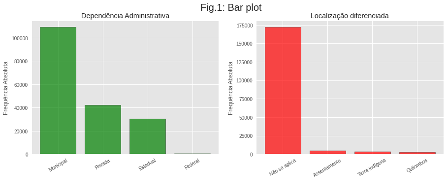

```python
figura = plt.figure(figsize=(15,5))

figura.add_subplot(1,2,1)
plt.title('Dependência Administrativa')
plt.ylabel('Frequência Absoluta')
plt.xticks(rotation=30)
plt.tick_params(labelsize=10)
plt.bar(['Municipal', 'Privada', 'Estadual', 'Federal'], escolas['TP_DEPENDENCIA'].value_counts(), color='green', alpha=0.7, edgecolor='black');

figura.add_subplot(1,2,2)
plt.title('Localização diferenciada')
plt.ylabel('Frequência Absoluta')
plt.tick_params(labelsize=10)
plt.xticks(rotation=30)
plt.bar(['Não se aplica', 'Assentamento', 'Terra indígena', 'Quilombos'], escolas['TP_LOCALIZACAO_DIFERENCIADA'].value_counts(), color='red', alpha=0.7, edgecolor='black');

figura.suptitle(nfig()+'Bar plot', fontsize=20)

plt.show();
```

- **Dependência Administrativa**: Nesse gráfico podemos observar que a grande maioria das escolas possui dependência administrativa associada a esfera municipal, seguido pela privada e estadual.
- **Localização diferenciada**: O atributo de localização diferenciada diz respeito a localização não habitual em que a escola pode se situar, como era de se esperar, são poucas as escolas que se encontram nessas localidades.

#### 3.1.2 Base de turmas

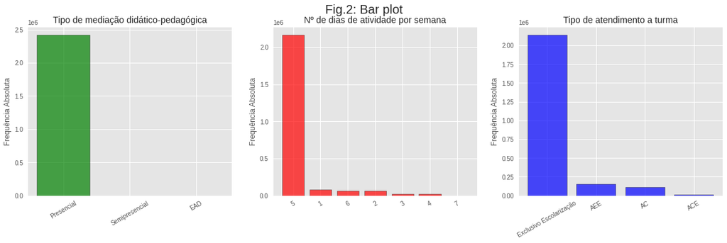

```python
figura = plt.figure(figsize=(20,5))

figura.add_subplot(1,3,1)
plt.title('Tipo de mediação didático-pedagógica')
plt.ylabel('Frequência Absoluta')
plt.xticks(rotation=30)
plt.tick_params(labelsize=10)
plt.bar(['Presencial', 'Semipresencial', 'EAD'], turmas['TP_MEDIACAO_DIDATICO_PEDAGO'].value_counts(), color='green', alpha=0.7, edgecolor='black');

figura.add_subplot(1,3,2)
plt.title('Nº de dias de atividade por semana')
plt.xticks(rotation=30)
plt.ylabel('Frequência Absoluta')
plt.tick_params(labelsize=10)
plt.bar(['5', '1', '6', '2', '3', '4', '7'], turmas['NU_DIAS_ATIVIDADE'].value_counts(), color='red', alpha=0.7, edgecolor='black')

figura.add_subplot(1,3,3)
plt.title('Tipo de atendimento a turma')
plt.xticks(rotation=30)
plt.ylabel('Frequência Absoluta')
plt.tick_params(labelsize=10)
plt.bar(['Exclusivo Escolarização', 'AEE', 'AC', 'ACE'], turmas['TP_TIPO_ATENDIMENTO_TURMA'].value_counts(), color='blue', alpha=0.7, edgecolor='black')

figura.suptitle(nfig()+'Bar plot', fontsize=20)

plt.show()
```

- **Tipo de mediação didático-pedagógica**: Este gráfico nos mostra que a modalidade presencial é a principal forma de mediação das aulas, isso se explica pelo fato de que no Brasil os regimes semipresenciais e EAD são mais encontrados no ensino superior.
- **Nº de dias de atividade**: Este atributo nos mostra a quantidade de dias em que são realizadas atividades escolares (aulas), aqui é clara a predominância de 5 dias semanais nas escolas consultadas pelo censo, fato que se deve a cultura de se ter aulas de "Segunda à Sexta" e folgas nos fins de semana.
- **Tipo de atendimento a turma**: Os tipo de atendimento de turma, podem ser: Exclusivo escolarização, atividade complementar e escolarização, atividade complementar e atendimento educacional especial. A grande maioria das turmas são do tipo exclusivo escolarização, como é esperado.

#### 3.1.3 Base de matrículas

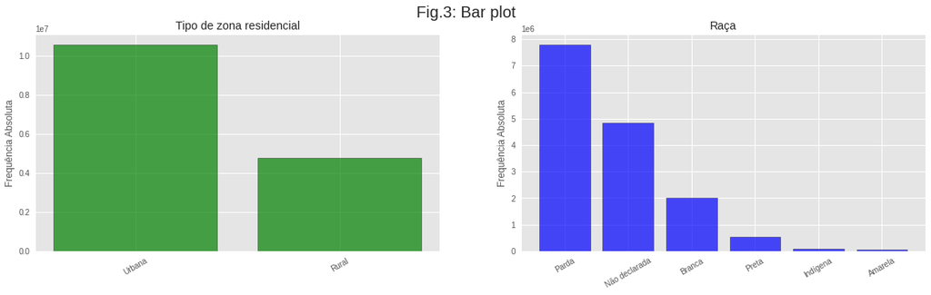

```python
figura = plt.figure(figsize=(20,5))

figura.add_subplot(1,2,1)
plt.title('Tipo de zona residencial')
plt.xticks(rotation=30)
plt.ylabel('Frequência Absoluta')
plt.tick_params(labelsize=10)
plt.bar(['Urbana', 'Rural'], matriculas['TP_ZONA_RESIDENCIAL'].value_counts(), color='green', alpha=0.7, edgecolor='black');

figura.add_subplot(1,2,2)
plt.title('Raça')
plt.xticks(rotation=30)
plt.ylabel('Frequência Absoluta')
plt.tick_params(labelsize=10)
plt.bar(['Parda', 'Não declarada','Branca','Preta', 'Indígena', 'Amarela'], matriculas['TP_COR_RACA'].value_counts(), color='blue', alpha=0.7, edgecolor='black')

figura.suptitle(nfig()+'Bar plot', fontsize=20)

plt.show()
```

#### 3.1.4 Base de docentes

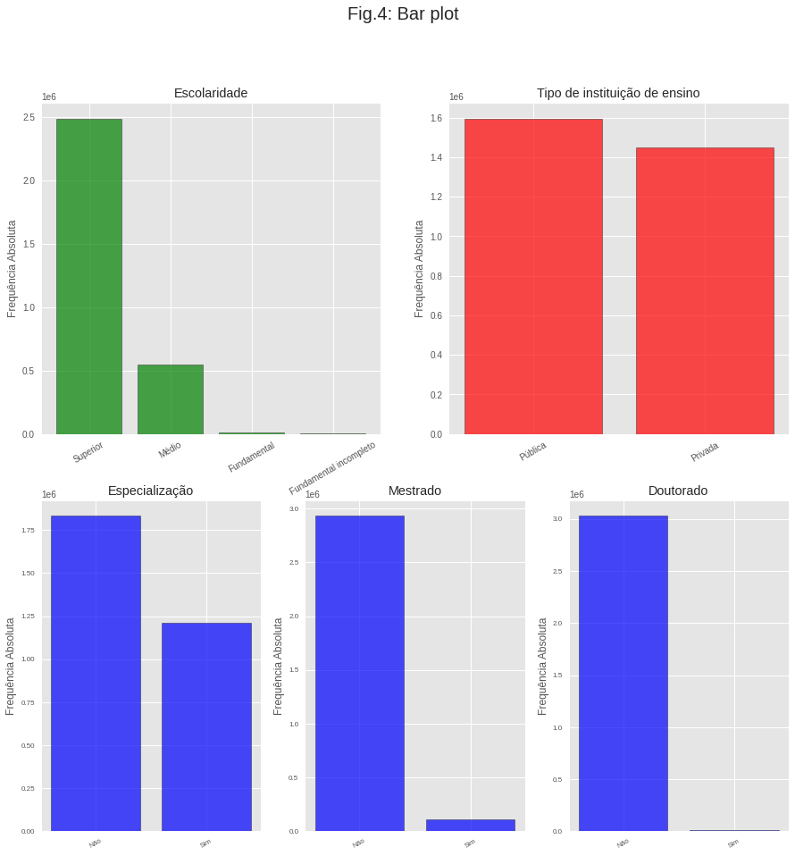

```python
figura = plt.figure(figsize=(15,15))

figura.add_subplot(2,2,1)
plt.title('Escolaridade')
plt.xticks(rotation=30)
plt.ylabel('Frequência Absoluta')
plt.bar(['Superior', 'Médio', 'Fundamental', 'Fundamental incompleto'], docentes['TP_ESCOLARIDADE'].value_counts(), color='green', alpha=0.7, edgecolor='black');

figura.add_subplot(2,2,2)
plt.title('Tipo de instituição de ensino')
plt.xticks(rotation=30)
plt.ylabel('Frequência Absoluta')
plt.bar(['Pública', 'Privada'], docentes['TP_TIPO_IES_1'].value_counts(), color='red', alpha=0.7, edgecolor='black')

figura.add_subplot(2,3,4)
plt.title('Especialização')
plt.xticks(rotation=30)
plt.ylabel('Frequência Absoluta')
plt.tick_params(labelsize=8)
plt.bar(['Não', 'Sim'], docentes['IN_ESPECIALIZACAO'].value_counts(), color='blue', alpha=0.7, edgecolor='black')

figura.add_subplot(2,3,5)
plt.title('Mestrado')
plt.xticks(rotation=30)
plt.ylabel('Frequência Absoluta')
plt.tick_params(labelsize=8)
plt.bar(['Não', 'Sim'], docentes['IN_MESTRADO'].value_counts(), color='blue', alpha=0.7, edgecolor='black')

figura.add_subplot(2,3,6)
plt.title('Doutorado')
plt.xticks(rotation=30)
plt.ylabel('Frequência Absoluta')
plt.tick_params(labelsize=8)
plt.bar(['Não', 'Sim'], docentes['IN_DOUTORADO'].value_counts(), color='blue', alpha=0.7, edgecolor='black')

figura.suptitle(nfig()+'Bar plot', fontsize=20)

plt.show()
```

- **Escolaridade**: Como é de se esperar, a maior parte dos docentes presentes no censo possui ensino superior completo, embora uma fatia considerável possua apenas ensino médio ou abaixo.
- **Tipo de instituição de ensino**: Este histograma nos mostra que há uma certa proximidade entra a quantidade de docentes formados em faculdades públicas e privadas, embora ainda haja mais docentes formados em escolas públicas.
- **Especialização, Mestrado e Doutorado**: Estes 3 atributos tratam sobre a existência de especialização, mestrado e doutorado no currículo do docente. Percebe-se que quanto maior o grau de formação, menor é quantidade de professores que possuem esta formação.

### 3.2 Análise de dispersão das notas

#### 3.2.1 Análise de dispersão das notas no Brasil

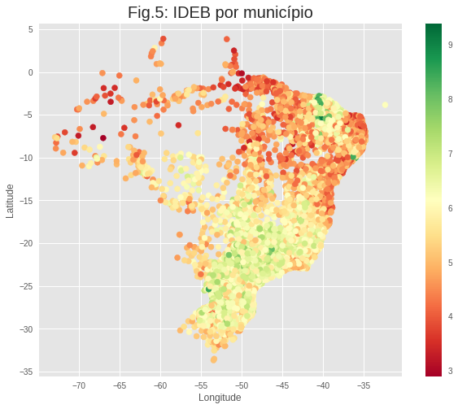

```python
plt.figure(figsize=(10,8))
plt.scatter(y=ideb_municipios['latitude'], x=ideb_municipios['longitude'],
            c=ideb_municipios['NOTA_IDEB'],
            cmap='RdYlGn')
plt.colorbar()
plt.xlabel('Longitude')
plt.ylabel('Latitude')
plt.title(nfig()+'IDEB por município', fontsize=20);
```

Podemos ver que as notas médias mais estáveis se concentram mais ao sul e suldestes, enquanto no nordeste e na parte superior do norte se concentram nas notas mais baixas, com exceções no Ceará. A partir do gráfico, poderemos comparar a dispersão das notas com a dispersão dos clusters futuramente, caso encontremos diferenças nas médias de notas nos clusters.

#### 3.2.2 Análise da dispersão das notas no estado do Ceará

```python
ideb_ce = ideb_municipios.filter(items=['latitude','longitude','NOTA_IDEB']).where(ideb_municipios.UF=='CE')
```

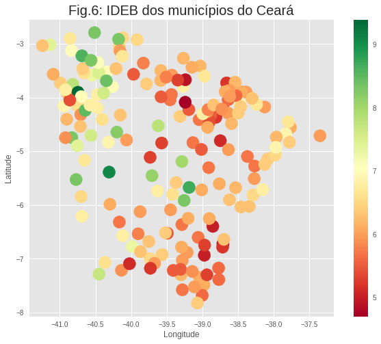

```python
plt.figure(figsize=(10,8))
plt.scatter(y=ideb_ce['latitude'], x=ideb_ce['longitude'],
            c=ideb_ce['NOTA_IDEB'],
            cmap='RdYlGn', s=325)
plt.colorbar()
plt.xlabel('Longitude')
plt.ylabel('Latitude')
plt.title(nfig()+'IDEB dos municípios do Ceará', fontsize=20);
```

Analisando o gráfico de dispersão de notas do Ceará, podemos ver que mesmo dentro do estado ainda há um certa discrepânica nas notas, onde existem notas baixas próximas as notas altas.

## 4. Criação e avaliação dos modelos

Avaliaremos o desempenho do Kmeans e do Kmodes. O Kmodes, menos conhecido, ao invés de calcular a distância numérica entre os clusters, avalia as k modas e a similaridade de entre as amostras para realizar o agrupamento. Para a avaliação dos resultados, utilizaremos o método do cotovelo e da silhueta. No método do cotovelo, avaliaremos o custo de agrupamento para cada número de clusters, e no método da silhueta avaliaremos o tamanho e distância entre os clusters.

### 4.1 Primeira Parte - Clusterização para redução de dimensionalidade

#### 4.1.1 Kmeans com One Hot Encoded

#### 4.1.1.1 Escolas

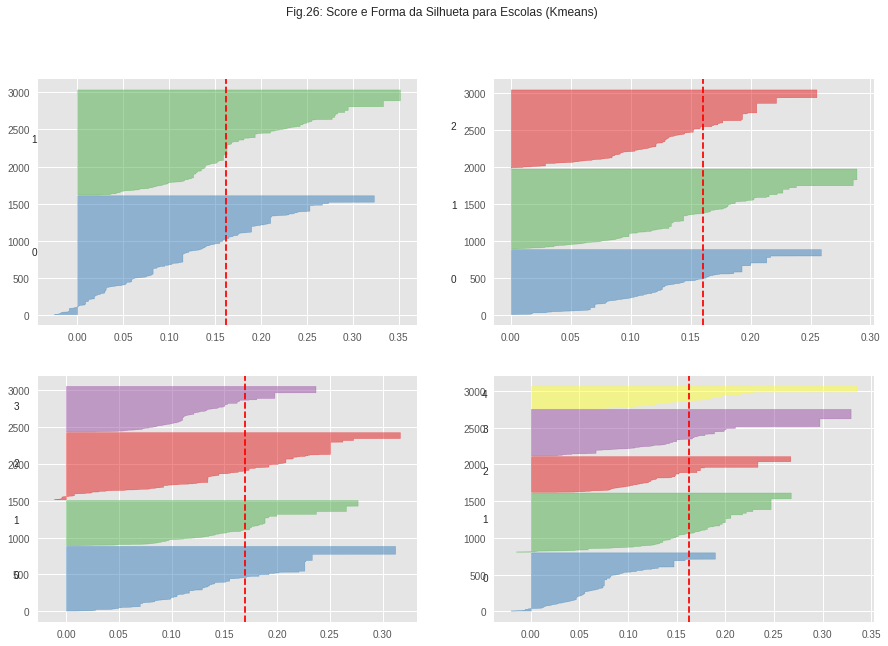

```python
cost = []
fig, ax = plt.subplots(2, 2, figsize=(15,10))
fig.suptitle(nfig()+'Score e Forma da Silhueta para Escolas (Kmeans)')
for i in [2, 3, 4, 5]:

    km = KMeans(n_clusters=i, max_iter=100)
    km.fit(escolas_ce_ohe)
    q, mod = divmod(i, 2)

    visualizer = SilhouetteVisualizer(km, colors='yellowbrick', ax=ax[q-1][mod])
    visualizer.fit(escolas_ce_ohe)
    cost.append(km.inertia_)
```

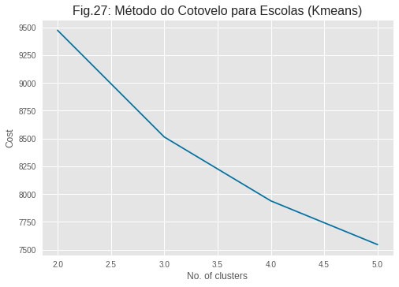

```python
plt.plot([2, 3, 4, 5], cost, 'bx-')
plt.xlabel('No. of clusters')
plt.ylabel('Cost')
plt.title(nfig()+'Método do Cotovelo para Escolas (Kmeans)', fontsize=16)
plt.show()
```

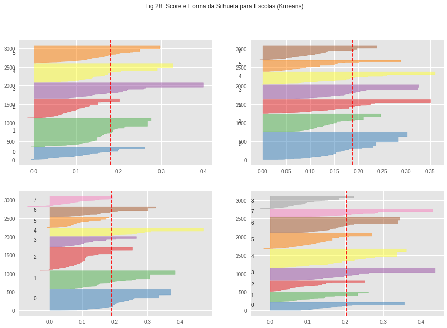

```python
#
#
#Segunda parte
fig, ax = plt.subplots(2, 2, figsize=(15,10))
fig.suptitle(nfig()+'Score e Forma da Silhueta para Escolas (Kmeans)')
for i in [6, 7, 8 , 9]:

    km = KMeans(n_clusters=i, max_iter=100)
    km.fit(escolas_ce_ohe)
    q, mod = divmod(i, 2)

    visualizer = SilhouetteVisualizer(km, colors='yellowbrick', ax=ax[q-3][mod])
    visualizer.fit(escolas_ce_ohe)
    cost.append(km.inertia_)
```

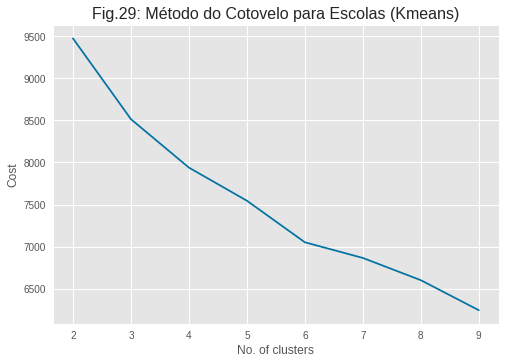

```python
plt.plot([2, 3, 4, 5, 6, 7, 8 , 9], cost, 'bx-')
plt.xlabel('No. of clusters')
plt.ylabel('Cost')
plt.title(nfig()+'Método do Cotovelo para Escolas (Kmeans)', fontsize=16)
plt.show()
```

#### 4.1.1.2 Turmas

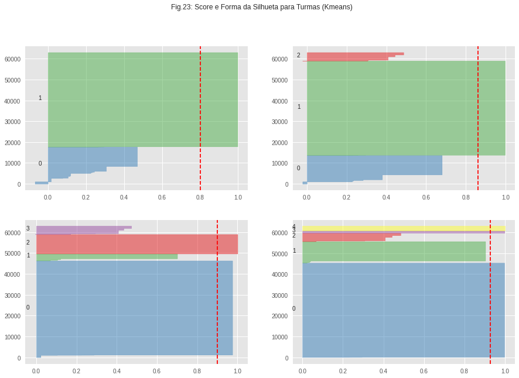

```python
cost = []
fig, ax = plt.subplots(2, 2, figsize=(15,10))
fig.suptitle(nfig()+'Score e Forma da Silhueta para Turmas (Kmeans)')
for i in [2, 3, 4, 5]:

    km = KMeans(n_clusters=i, max_iter=100)
    km.fit(turmas_ce_ohe)
    q, mod = divmod(i, 2)

    visualizer = SilhouetteVisualizer(km, colors='yellowbrick', ax=ax[q-1][mod])
    visualizer.fit(turmas_ce_ohe)
    cost.append(km.inertia_)
```

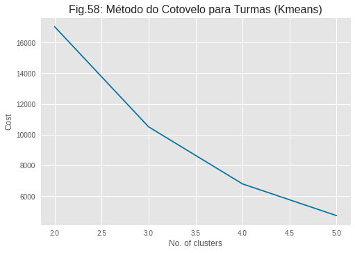

```python
plt.plot([2,3,4,5],cost, 'bx-')
plt.xlabel('No. of clusters')
plt.ylabel('Cost')
plt.title(nfig()+'Método do Cotovelo para Turmas (Kmeans)', fontsize=16)
plt.show()
```

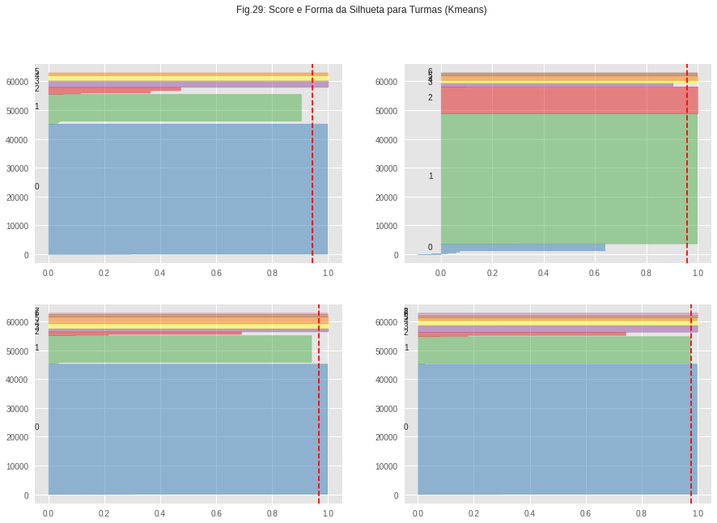

```python
#
#
#Segunda parte
fig, ax = plt.subplots(2, 2, figsize=(15,10))
fig.suptitle(nfig()+'Score e Forma da Silhueta para Turmas (Kmeans)')
for i in [6, 7, 8 , 9]:

    km = KMeans(n_clusters=i, max_iter=100)
    km.fit(turmas_ce_ohe)
    q, mod = divmod(i, 2)

    visualizer = SilhouetteVisualizer(km, colors='yellowbrick', ax=ax[q-3][mod])
    visualizer.fit(turmas_ce_ohe)
    cost.append(km.inertia_)
```

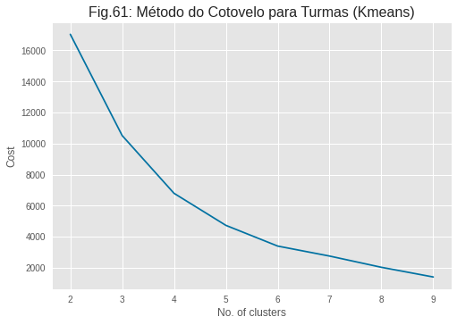

```python
plt.plot([2,3,4,5,6,7,8,9],cost, 'bx-')
plt.xlabel('No. of clusters')
plt.ylabel('Cost')
plt.title(nfig()+'Método do Cotovelo para Turmas (Kmeans)', fontsize=16)
plt.show()
```

Em turmas, o método do cotovelo também não nos fornece um bom indicativo para a escolha de um bom K. Partindo para o método da silhueta, encontramos bons resultados de score, mas não encontramos uma boa proporção entre os cluster, acabamos escolhendo k=7.

#### 4.1.1.3 Docentes

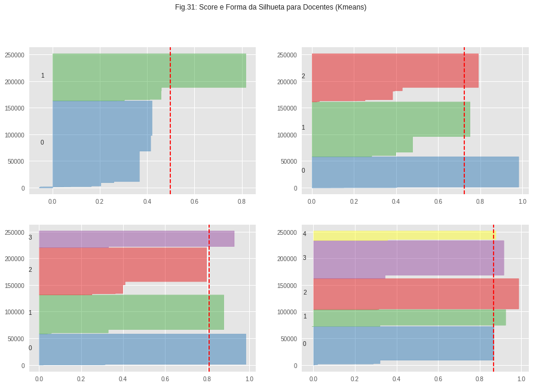

```python
cost = []
fig, ax = plt.subplots(2, 2, figsize=(15,10))
fig.suptitle(nfig()+'Score e Forma da Silhueta para Docentes (Kmeans)')
for i in [2, 3, 4, 5]:

    km = KMeans(n_clusters=i, max_iter=100)
    km.fit(docentes_ce_ohe)
    q, mod = divmod(i, 2)

    visualizer = SilhouetteVisualizer(km, colors='yellowbrick', ax=ax[q-1][mod])
    visualizer.fit(docentes_ce_ohe)
    cost.append(km.inertia_)
```

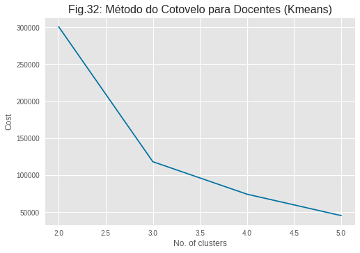

```python
plt.plot([2, 3, 4, 5], cost, 'bx-')
plt.xlabel('No. of clusters')
plt.ylabel('Cost')
plt.title(nfig()+'Método do Cotovelo para Docentes (Kmeans)', fontsize=16)
plt.show()
```

Pelo método do cotovelo, podemos ver que o k=3 seria um boa escolha mas, olhando para a sua respectiva forma de silhueta, podemos ver que a sua proporção não é tão boa. Olhando para o score e proporção dos clusters, escolhemos o k=5.

#### 4.1.1.4 Matrículas

```python
pca = PCA(n_components=3)
principalComponents_matriculas = pca.fit_transform(matriculas_ce_Ideb)

principal_breast_Df = pd.DataFrame(data = principalComponents_matriculas
             , columns = ['PC1', 'PC2', 'PC3'])

print('Explained variation per principal component: {}'.format(pca.explained_variance_ratio_))
```

```
Explained variation per principal component: [1.00000000e+00 1.78747356e-10 3.65031358e-11]
```

```python
principal_breast_Df.info()
```

```
<class 'pandas.core.frame.DataFrame'>
RangeIndex: 1405544 entries, 0 to 1405543
Data columns (total 3 columns):
 #   Column  Non-Null Count    Dtype
---  ------  --------------    -----
 0   PC1     1405544 non-null  float64
 1   PC2     1405544 non-null  float64
 2   PC3     1405544 non-null  float64
dtypes: float64(3)
memory usage: 32.2 MB
```

```python
df_matriculas_percent = principal_breast_Df.sample(frac=0.2)
```

```python
df_matriculas_percent.info()
```

```
<class 'pandas.core.frame.DataFrame'>
Int64Index: 281109 entries, 555543 to 596233
Data columns (total 3 columns):
 #   Column  Non-Null Count   Dtype
---  ------  --------------   -----
 0   PC1     281109 non-null  float64
 1   PC2     281109 non-null  float64
 2   PC3     281109 non-null  float64
dtypes: float64(3)
memory usage: 8.6 MB
```

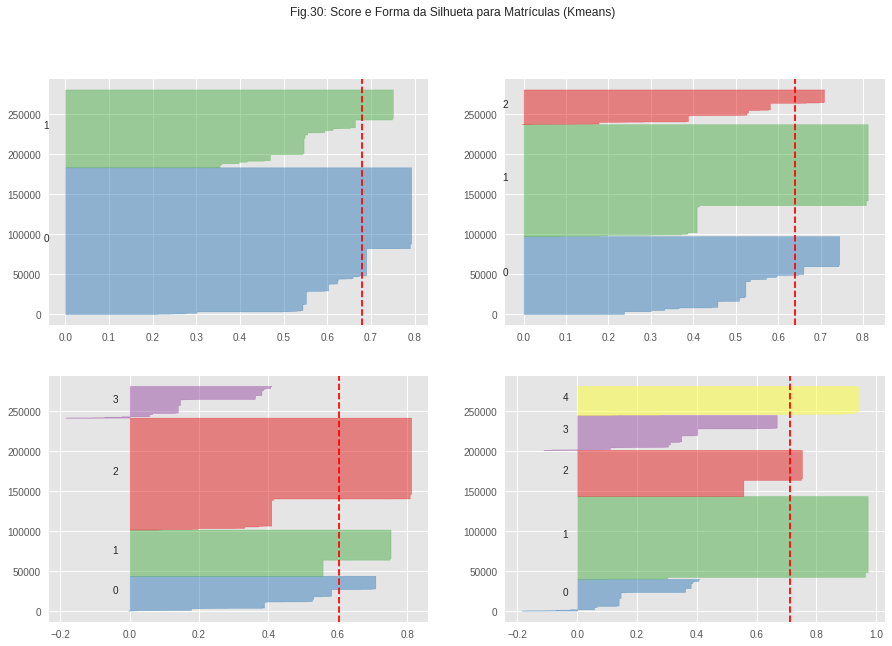

```python
cost = []
fig, ax = plt.subplots(2, 2, figsize=(15,10))
fig.suptitle(nfig()+'Score e Forma da Silhueta para Matrículas (Kmeans)')
for i in [2, 3, 4, 5]:

    km = KMeans(n_clusters=i, max_iter=100)
    km.fit(df_matriculas_percent)
    q, mod = divmod(i, 2)

    visualizer = SilhouetteVisualizer(km, colors='yellowbrick', ax=ax[q-1][mod])
    visualizer.fit(df_matriculas_percent)
    cost.append(km.inertia_)
```

[figure not shown]

```python
plt.plot([2, 3, 4, 5], cost, 'bx-')
plt.xlabel('No. of clusters')
plt.ylabel('Cost')
plt.title(nfig()+'Método do Cotovelo para Matrícula (Kmeans)', fontsize=16)
plt.show()
```

Em matrículas, tivemos problemas no processamento dos dados, onde o tempo execução dos modelos estavam inviabilizando a continuidade do trabalho, com execuções durando mais de 8hrs e sem terem terminado ainda, por exemplo. Para driblar esse problema, aplicamos o PCA e reduzimos o conjunto de dados para 20% do tamanho original. Ainda assim, a execução demorou pouco mais de 2hrs, como obtivemos um resultado interessante com k=3, escolhemos esse número.

#### 4.1.2 Kmodes com One Hot Encoded

Acreditamos que o Kmodes apresentaria os melhores resultados por conta da sua natureza ser voltada para variáveis categóricas e booleanas, porem o Kmeans apresentou resultados melhores. A seguir, pode-ser ver que os resultados das silhuetas do Kmodes não são tão coesos como no Kmeans.

##### 4.1.2.1 Docentes

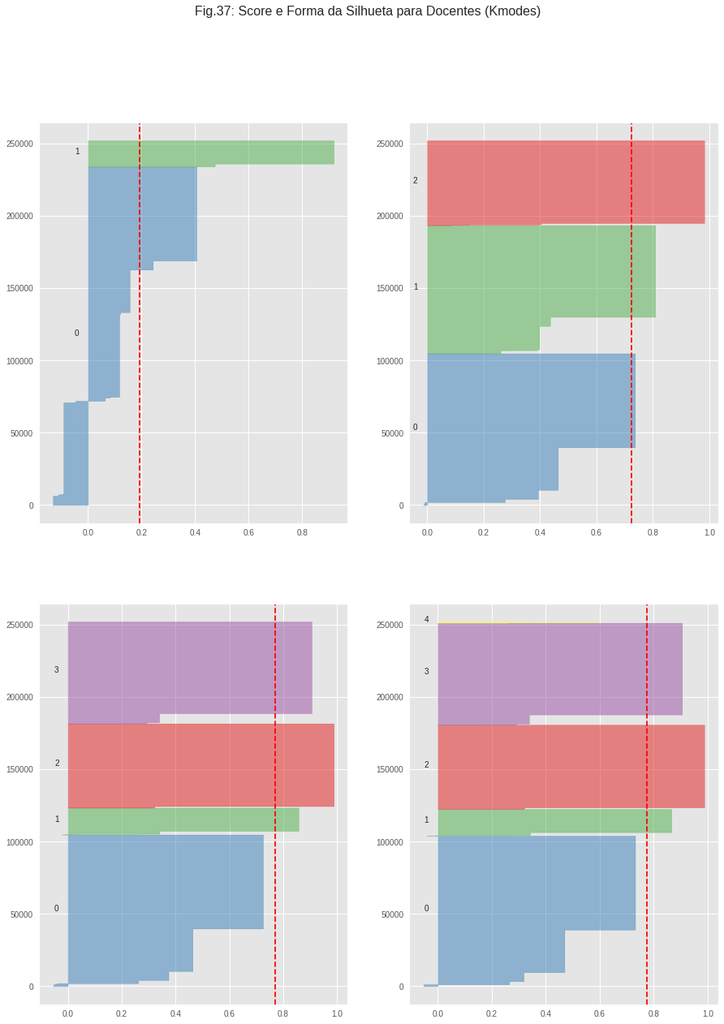

```python
cost = []
fig, ax = plt.subplots(2, 2, figsize=(15,20))
fig.suptitle(nfig()+'Score e Forma da Silhueta para Docentes (Kmodes)', fontsize=16)
for i in [2, 3, 4, 5]:

    km = KModes(n_clusters=i, max_iter=50,  init = "Cao", n_init = 1, verbose=0)
    q, mod = divmod(i, 2)

    visualizer = SilhouetteVisualizer(km, colors='yellowbrick', ax=ax[q-1][mod])
    visualizer.fit(docentes_ce_ohe)
    cost.append(km.cost_)
```

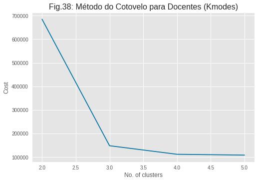

```python
plt.plot([2, 3, 4, 5], cost, 'bx-')
plt.xlabel('No. of clusters')
plt.ylabel('Cost')
plt.title(nfig()+'Método do Cotovelo para Docentes (Kmodes)', fontsize=16)
plt.show()
```

##### 4.1.2.2 Escolas

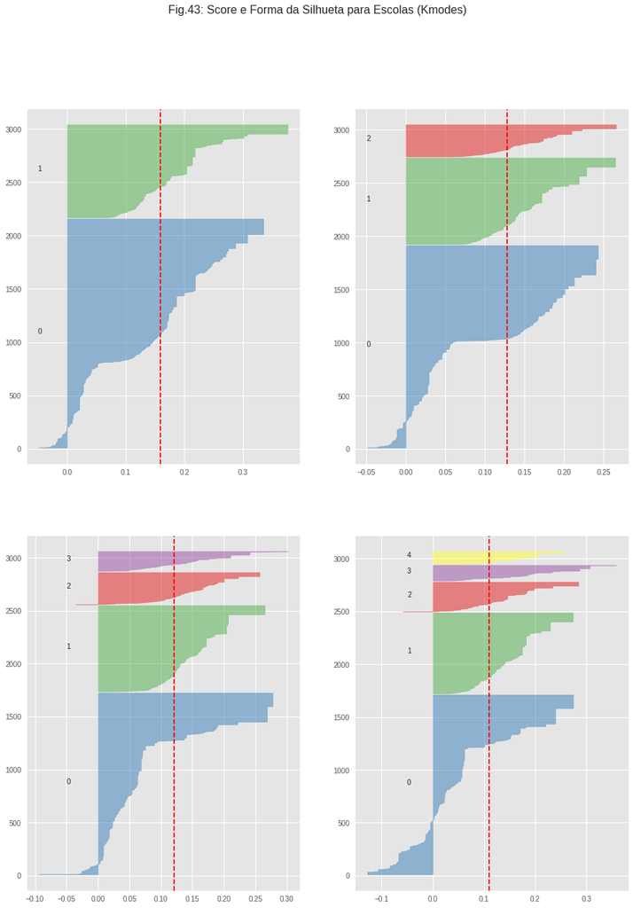

```python
cost = []
fig, ax = plt.subplots(2, 2, figsize=(15,20))
fig.suptitle(nfig()+'Score e Forma da Silhueta para Escolas (Kmodes)', fontsize=16)
for i in [2, 3, 4, 5]:

    km = KModes(n_clusters=i, max_iter=50,  init = "Cao", n_init = 1, verbose=0)
    q, mod = divmod(i, 2)

    visualizer = SilhouetteVisualizer(km, colors='yellowbrick', ax=ax[q-1][mod])
    visualizer.fit(escolas_ce_ohe)
    cost.append(km.cost_)
```

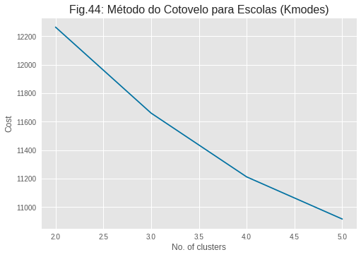

```python
plt.plot([2, 3, 4, 5], cost, 'bx-')
plt.xlabel('No. of clusters')
plt.ylabel('Cost')
plt.title(nfig()+'Método do Cotovelo para Escolas (Kmodes)', fontsize=16)
plt.show()
```

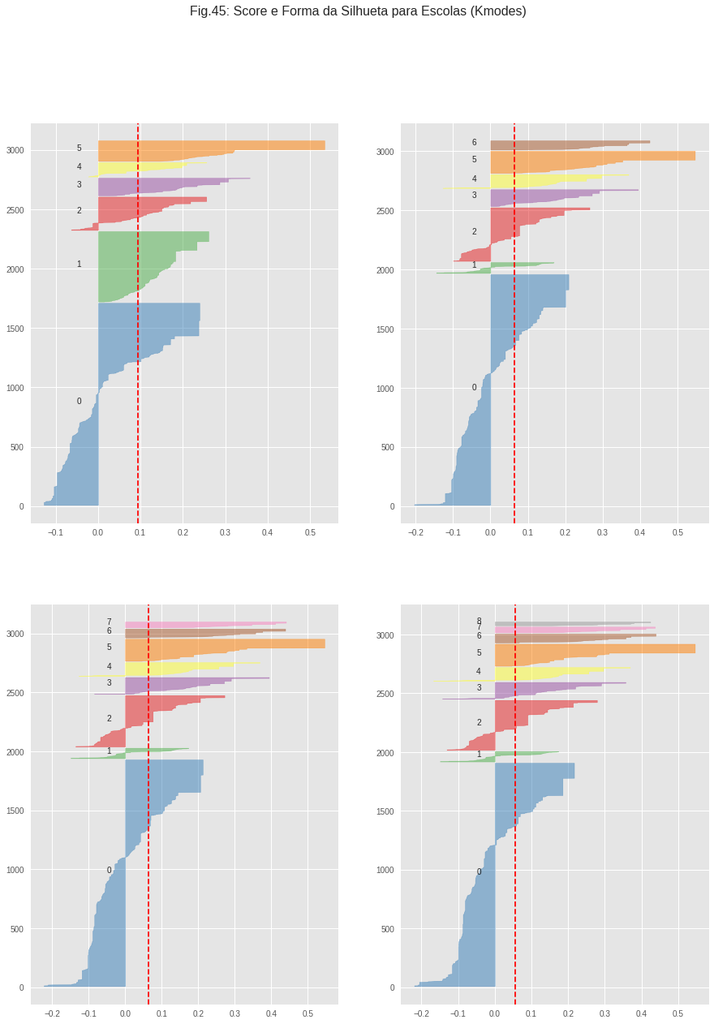

```python
#
#
# Segunda parte
fig, ax = plt.subplots(2, 2, figsize=(15,20))
fig.suptitle(nfig()+'Score e Forma da Silhueta para Escolas (Kmodes)', fontsize=16)
for i in [6, 7, 8 , 9]:

    km = KModes(n_clusters=i, max_iter=50,  init = "Cao", n_init = 1, verbose=0)
    q, mod = divmod(i, 2)

    visualizer = SilhouetteVisualizer(km, colors='yellowbrick', ax=ax[q-3][mod])
    visualizer.fit(escolas_ce_ohe)
    cost.append(km.cost_)
```

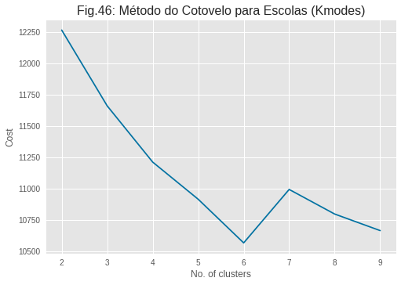

```python
plt.plot([2, 3, 4, 5, 6, 7, 8 , 9], cost, 'bx-')
plt.xlabel('No. of clusters')
plt.ylabel('Cost')
plt.title(nfig()+'Método do Cotovelo para Escolas (Kmodes)', fontsize=16)
plt.show()
```

##### 4.1.2.3 Matrículas

##### 4.1.2.4 Turmas

```python
cost = []
fig, ax = plt.subplots(2, 2, figsize=(15,20))
fig.suptitle(nfig()+'Score e Forma da Silhueta para Turmas (Kmodes)')
for i in [2, 3, 4, 5]:

    km = KModes(n_clusters=i, max_iter=50,  init = "Cao", n_init = 1, verbose=0)
    q, mod = divmod(i, 2)

    visualizer = SilhouetteVisualizer(km, colors='yellowbrick', ax=ax[q-1][mod])
    visualizer.fit(turmas_ce_ohe)
    cost.append(km.cost_)
```

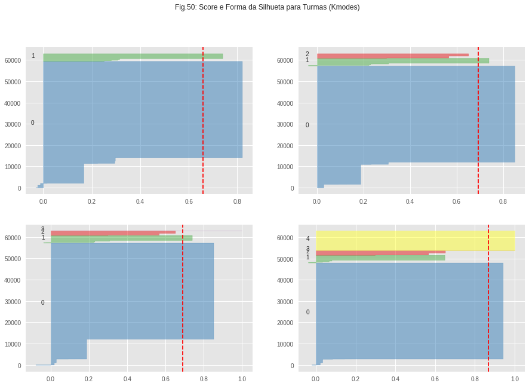

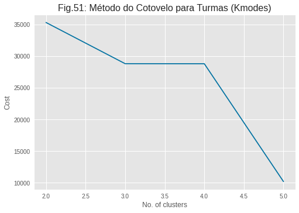

```python
plt.plot([2, 3, 4, 5], cost, 'bx-')
plt.xlabel('No. of clusters')
plt.ylabel('Cost')
plt.title(nfig()+'Método do Cotovelo para Turmas (Kmodes)', fontsize=16)
plt.show()
```

```python
#
#
# Segunda parte
fig, ax = plt.subplots(2, 2, figsize=(15,20))
fig.suptitle(nfig()+'Score e Forma da Silhueta para Turmas (Kmodes)', fontsize=16)
for i in [6, 7, 8 , 9]:

    km = KModes(n_clusters=i, max_iter=50,  init = "Cao", n_init = 1, verbose=0)
    q, mod = divmod(i, 2)

    visualizer = SilhouetteVisualizer(km, colors='yellowbrick', ax=ax[q-3][mod])
    visualizer.fit(turmas_ce_ohe)
    cost.append(km.cost_)
```

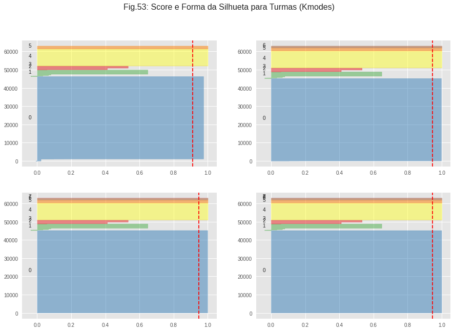

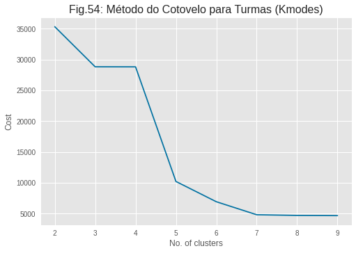

```python
plt.plot([2, 3, 4, 5, 6, 7, 8 , 9], cost, 'bx-')
plt.xlabel('No. of clusters')
plt.ylabel('Cost')
plt.title(nfig()+'Método do Cotovelo para Turmas (Kmodes)', fontsize=16)
plt.show()
```

#### 4.1.3 Escolha dos modelos

##### 4.1.3.1 Escolas

Dado os testes realizados, próximos para utilizar cada modelo com os k's escolhidos.

```python
km = KMeans(n_clusters=7, max_iter=100)
escolas_cluster = km.fit_predict(escolas_ce_ohe)
```

Em seguida, anexamos as classificações no conjunto de dados.

```python
escolas_ce_Ideb['CLUSTER'] = escolas_cluster
```

Para facilitar a continuidade do trabalho depois de encerrarmos a sessão do colab, salvamos os resuldados para utizarmos prosteriormente sem precisarmos executar todo o pipe novamente.

```python
escolas_ce_Ideb.to_csv(general_path+'escolas_ce_cluster', encoding='ISO-8859-1', index=False)
```

##### 4.1.3.2 Turmas

Os procedimentos nos outros conjuntos são análogos.

```python
turmas_ce_Ideb = turmas_ce.merge(IDEB_geral, how = 'inner', left_on='CO_ENTIDADE', right_on='COD_ESCOLA')
turmas_ce_Ideb.drop(columns=['NOTA_IDEB', 'CO_UF', 'COD_ESCOLA'], inplace=True)
```

```python
km = KMeans(n_clusters=7, max_iter=100)
turmas_cluster = km.fit_predict(turmas_ce_ohe)
```

```python
turmas_ce_Ideb['CLUSTER'] = turmas_cluster
```

```python
turmas_ce_Ideb.to_csv(general_path+'turmas_ce_cluster', encoding='ISO-8859-1', index=False)
```

##### 4.1.3.3 Docentes

```python
docentes_ce_Ideb = docentes_ce.merge(IDEB_geral, how = 'inner', left_on='CO_ENTIDADE', right_on='COD_ESCOLA')
docentes_ce_Ideb.drop(columns=['NOTA_IDEB', 'CO_UF', 'COD_ESCOLA'], inplace=True)
```

```python
km = KMeans(n_clusters=5, max_iter=100)
docentes_cluster = km.fit_predict(docentes_ce_ohe)
```

```python
docentes_ce_Ideb['CLUSTER'] = docentes_cluster
docentes_ce_Ideb.to_csv(general_path+'docentes_ce_cluster', encoding='ISO-8859-1', index=False)
```

##### 4.1.3.4 Matrículas

```python
matriculas_ce_Ideb = matriculas_ce.merge(IDEB_geral, how = 'inner', left_on='CO_ENTIDADE', right_on='COD_ESCOLA')
matriculas_ce_Ideb.drop(columns=['NOTA_IDEB', 'CO_UF', 'COD_ESCOLA'], inplace=True)
```

```python
matriculas_ce_Ideb_frac = matriculas_ce_Ideb.sample(frac=0.2)
matriculas_copy = matriculas_ce_Ideb_frac
```

```python
pca = PCA(n_components=3)
pca.fit(matriculas_ce_Ideb)
principalComponents_matriculas = pca.transform(matriculas_copy)

matriculas_ce_pca = pd.DataFrame(data = principalComponents_matriculas
             , columns = ['PC1', 'PC2', 'PC3'])
```

```python
km = KMeans(n_clusters=3, max_iter=100)
matriculas_cluster = km.fit_predict(matriculas_ce_pca)
```

```python
matriculas_copy['CLUSTER'] = matriculas_cluster
matriculas_copy.to_csv(general_path+'matriculas_ce_cluster', encoding='ISO-8859-1', index=False)
```

### 4.2 Segunda Parte - Criação do modelo para clusterização das escolas

#### 4.2.1 Pré-processamento dos resultados da primeira parte

Agora, executaremos a contagem da incidência de cada categoria nos conjuntos para reduzirmos a dimensionalidade.

##### 4.2.1.1 Matrículas

Primeiro, importamos os resultados da primeira clusterização.

```python
matriculas_cluster = pd.read_csv(general_path+'matriculas_ce_cluster', encoding='ISO-8859-1', sep=',')
matriculas_cluster.head()
```

|  | TP_COR_RACA | TP_ZONA_RESIDENCIAL | TP_LOCAL_RESID_DIFERENCIADA | IN_NECESSIDADE_ESPECIAL | IN_TRANSPORTE_PUBLICO | IN_TRANSP_BICICLETA | IN_TRANSP_MICRO_ONIBUS | IN_TRANSP_ONIBUS | IN_TRANSP_TR_ANIMAL | IN_TRANSP_VANS_KOMBI | IN_TRANSP_OUTRO_VEICULO | CO_ENTIDADE | CLUSTER |
| --- | --- | --- | --- | --- | --- | --- | --- | --- | --- | --- | --- | --- | --- |
| 0 | 3 | 1 | 0 | 0 | 0 | 0 | 0 | 0 | 0 | 0 | 0 | 23124920 | 0 |
| 1 | 3 | 1 | 0 | 0 | 0 | 0 | 0 | 0 | 0 | 0 | 0 | 23067756 | 0 |
| 2 | 3 | 1 | 0 | 0 | 0 | 0 | 0 | 0 | 0 | 0 | 0 | 23222662 | 1 |
| 3 | 0 | 1 | 0 | 0 | 0 | 0 | 0 | 0 | 0 | 0 | 0 | 23223219 | 1 |
| 4 | 3 | 2 | 0 | 0 | 1 | 0 | 0 | 0 | 0 | 1 | 0 | 23010568 | 0 |

Em seguida, criamos um dataframe com somente os codigos das escolas.

```python
co_escolas = matriculas_cluster['CO_ENTIDADE'].unique()
df_matriculas_cluster = pd.DataFrame(data=co_escolas,columns=['CO_ENTIDADE'])
```

E então criamos uma nova coluna para cada cluster. A ideia é criar as k colunas, uma para cada cluster, para depois atualizarmos o seu valor com o número de indicências de cada cluster para a referida escola.

```python
df_matriculas_cluster[0] = 0
df_matriculas_cluster[1] = 0
df_matriculas_cluster[2] = 0
df_matriculas_cluster.info()
```

```
<class 'pandas.core.frame.DataFrame'>
RangeIndex: 3021 entries, 0 to 3020
Data columns (total 4 columns):
 #   Column       Non-Null Count  Dtype
---  ------       --------------  -----
 0   CO_ENTIDADE  3021 non-null   int64
 1   0            3021 non-null   int64
 2   1            3021 non-null   int64
 3   2            3021 non-null   int64
dtypes: int64(4)
memory usage: 94.5 KB
```

Em seguida, em um laço, para cada escola de ensino válida realizamos a contagem dos clusters das matrículas e associamos cada valor da contagem a uma coluna do referido cluster criado anteriormente.

```python
for i in range(len(co_escolas)):
    tpl = matriculas_cluster[matriculas_cluster['CO_ENTIDADE']==co_escolas[i]]['CLUSTER'].value_counts()
    df_matriculas_cluster.loc[df_matriculas_cluster['CO_ENTIDADE']==co_escolas[i],tpl.index] = tpl.values[0]
```

No caso de matrículas, cada escola ficou com somete 1 tipo de cluster.

```python
df_matriculas_cluster.head()
```

|  | CO_ENTIDADE | 0 | 1 | 2 |
| --- | --- | --- | --- | --- |
| 0 | 23124920 | 85 | 0 | 0 |
| 1 | 23067756 | 156 | 0 | 0 |
| 2 | 23222662 | 0 | 123 | 0 |
| 3 | 23223219 | 0 | 129 | 0 |
| 4 | 23010568 | 58 | 0 | 0 |

##### 4.2.1.2 Docentes

Os mesmos passos foram repeditos para os outros conjuntos.

```python
docentes_cluster = pd.read_csv(general_path+'docentes_ce_cluster', encoding='ISO-8859-1', sep=',')
docentes_cluster.head()
```

|  | TP_ESCOLARIDADE | TP_TIPO_IES_1 | IN_COMPLEMENTACAO_PEDAGOGICA | IN_ESPECIALIZACAO | IN_MESTRADO | IN_DOUTORADO | IN_POS_NENHUM | CO_ENTIDADE | CLUSTER |
| --- | --- | --- | --- | --- | --- | --- | --- | --- | --- |
| 0 | 4 | 1 | 0 | 1 | 0 | 0 | 0 | 23164247 | 0 |
| 1 | 4 | 1 | 0 | 1 | 0 | 0 | 0 | 23164247 | 0 |
| 2 | 4 | 1 | 0 | 1 | 0 | 0 | 0 | 23164247 | 0 |
| 3 | 4 | 1 | 0 | 1 | 0 | 0 | 0 | 23164247 | 0 |
| 4 | 4 | 1 | 0 | 1 | 0 | 0 | 0 | 23164247 | 0 |

```python
docentes_cluster['CLUSTER'].value_counts()
```

```
0    72436
3    71160
2    58197
1    31816
4    18311
Name: CLUSTER, dtype: int64
```

```python
df_docentes_cluster = pd.DataFrame(data=co_escolas,columns=['CO_ENTIDADE'])
```

```python
df_docentes_cluster[0] = 0
df_docentes_cluster[1] = 0
df_docentes_cluster[2] = 0
df_docentes_cluster[3] = 0
df_docentes_cluster[4] = 0
```

```python
for i in range(len(co_escolas)):
    tpl = docentes_cluster[docentes_cluster['CO_ENTIDADE']==co_escolas[i]]['CLUSTER'].value_counts()
    df_docentes_cluster.loc[df_docentes_cluster['CO_ENTIDADE']==co_escolas[i],tpl.index] = tpl.values
```

```python
df_docentes_cluster.head()
```

|  | CO_ENTIDADE | 0 | 1 | 2 | 3 | 4 |
| --- | --- | --- | --- | --- | --- | --- |
| 0 | 23124920 | 7 | 3 | 31 | 30 | 6 |
| 1 | 23067756 | 18 | 16 | 17 | 24 | 4 |
| 2 | 23222662 | 86 | 6 | 39 | 19 | 0 |
| 3 | 23223219 | 57 | 44 | 11 | 59 | 0 |
| 4 | 23010568 | 15 | 4 | 13 | 10 | 3 |

##### 4.2.1.3 Turmas

```python
turmas_cluster = pd.read_csv(general_path+'turmas_ce_cluster', encoding='ISO-8859-1', sep=',')
turmas_cluster.head()
```

|  | TP_MEDIACAO_DIDATICO_PEDAGO | NU_DIAS_ATIVIDADE | TP_TIPO_ATENDIMENTO_TURMA | CO_ENTIDADE | CLUSTER |
| --- | --- | --- | --- | --- | --- |
| 0 | 1 | 5 | 1 | 23165510 | 0 |
| 1 | 1 | 5 | 1 | 23165510 | 0 |
| 2 | 1 | 5 | 1 | 23165510 | 0 |
| 3 | 1 | 5 | 1 | 23165510 | 0 |
| 4 | 1 | 5 | 1 | 23165510 | 0 |

```python
turmas_cluster['CLUSTER'].value_counts()
```

```
0    45303
2     9296
3     2393
5     2335
4     1644
6     1057
1      999
Name: CLUSTER, dtype: int64
```

```python
df_turmas_cluster = pd.DataFrame(data=co_escolas,columns=['CO_ENTIDADE'])
```

```python
df_turmas_cluster[0] = 0
df_turmas_cluster[1] = 0
df_turmas_cluster[2] = 0
df_turmas_cluster[3] = 0
df_turmas_cluster[4] = 0
df_turmas_cluster[5] = 0
df_turmas_cluster[6] = 0
df_turmas_cluster.head()
```

|  | CO_ENTIDADE | 0 | 1 | 2 | 3 | 4 | 5 | 6 |
| --- | --- | --- | --- | --- | --- | --- | --- | --- |
| 0 | 23124920 | 0 | 0 | 0 | 0 | 0 | 0 | 0 |
| 1 | 23067756 | 0 | 0 | 0 | 0 | 0 | 0 | 0 |
| 2 | 23222662 | 0 | 0 | 0 | 0 | 0 | 0 | 0 |
| 3 | 23223219 | 0 | 0 | 0 | 0 | 0 | 0 | 0 |
| 4 | 23010568 | 0 | 0 | 0 | 0 | 0 | 0 | 0 |

```python
for i in range(len(co_escolas)):
    tpl = turmas_cluster[turmas_cluster['CO_ENTIDADE']==co_escolas[i]]['CLUSTER'].value_counts()
    df_turmas_cluster.loc[df_turmas_cluster['CO_ENTIDADE']==co_escolas[i],tpl.index] = tpl.values
```

```python
df_turmas_cluster.head()
```

|  | CO_ENTIDADE | 0 | 1 | 2 | 3 | 4 | 5 | 6 |
| --- | --- | --- | --- | --- | --- | --- | --- | --- |
| 0 | 23124920 | 17 | 4 | 0 | 0 | 0 | 0 | 0 |
| 1 | 23067756 | 26 | 0 | 4 | 0 | 2 | 0 | 0 |
| 2 | 23222662 | 11 | 0 | 6 | 2 | 0 | 0 | 3 |
| 3 | 23223219 | 15 | 0 | 10 | 3 | 0 | 0 | 0 |
| 4 | 23010568 | 11 | 0 | 4 | 0 | 0 | 0 | 0 |

##### 4.2.1.4 Escolas

```python
df_escolas_cluster = pd.read_csv(general_path+'escolas_ce_cluster', encoding='ISO-8859-1', sep=',')
df_escolas_cluster.head()
```

|  | TP_DEPENDENCIA | TP_LOCALIZACAO | TP_LOCALIZACAO_DIFERENCIADA | IN_VINCULO_SECRETARIA_EDUCACAO | IN_VINCULO_SEGURANCA_PUBLICA | TP_OCUPACAO_PREDIO_ESCOLAR | IN_LOCAL_FUNC_SOCIOEDUCATIVO | IN_LOCAL_FUNC_UNID_PRISIONAL | IN_LOCAL_FUNC_PRISIONAL_SOCIO | IN_LOCAL_FUNC_GALPAO | IN_ENERGIA_INEXISTENTE | IN_BIBLIOTECA | IN_LABORATORIO_CIENCIAS | IN_LABORATORIO_INFORMATICA | IN_ACESSIBILIDADE_INEXISTENTE | IN_EQUIP_MULTIMIDIA | IN_COMP_PORTATIL_ALUNO | IN_TABLET_ALUNO | IN_INTERNET | IN_MATERIAL_PED_CIENTIFICO | IN_EXAME_SELECAO | TP_PROPOSTA_PEDAGOGICA | CLUSTER |
| --- | --- | --- | --- | --- | --- | --- | --- | --- | --- | --- | --- | --- | --- | --- | --- | --- | --- | --- | --- | --- | --- | --- | --- |
| 0 | 3 | 1 | 0 | 1 | 0 | 1 | 0 | 0 | 0 | 0 | 0 | 1 | 0 | 1 | 0 | 1 | 1 | 0 | 1 | 0 | 0 | 1 | 5 |
| 1 | 3 | 1 | 0 | 1 | 0 | 1 | 0 | 0 | 0 | 0 | 0 | 0 | 0 | 1 | 0 | 1 | 0 | 0 | 1 | 0 | 0 | 1 | 4 |
| 2 | 3 | 2 | 0 | 1 | 0 | 1 | 0 | 0 | 0 | 0 | 0 | 0 | 0 | 1 | 0 | 0 | 0 | 0 | 1 | 9 | 0 | 1 | 4 |
| 3 | 3 | 1 | 0 | 1 | 0 | 1 | 0 | 0 | 0 | 0 | 0 | 0 | 0 | 1 | 0 | 1 | 0 | 0 | 1 | 9 | 0 | 1 | 4 |
| 4 | 3 | 1 | 0 | 1 | 0 | 1 | 0 | 0 | 0 | 0 | 0 | 0 | 0 | 0 | 0 | 1 | 0 | 0 | 1 | 1 | 0 | 1 | 1 |

```python
df_escolas_cluster['CO_ENTIDADE'] = co_escolas
```

##### 4.2.1.5 Juntando os conjuntos

```python
df_turmas_cluster = df_turmas_cluster.rename(columns = {0: '0_TU',
                                                        1: '1_TU',
                                                        2: '2_TU',
                                                        3: '3_TU',
                                                        4: '4_TU',
                                                        5: '5_TU',
                                                        6: '6_TU'}, inplace = False)

df_matriculas_cluster = df_matriculas_cluster.rename(columns = {0: '0_MA',
                                                                1: '1_MA',
                                                                2: '2_MA',
                                                                3: '3_MA',
                                                                4: '4_MA',
                                                                5: '5_MA',
                                                                6: '6_MA'}, inplace = False)

df_docentes_cluster = df_docentes_cluster.rename(columns = {0: '0_DO',
                                                            1: '1_DO',
                                                            2: '2_DO',
                                                            3: '3_DO',
                                                            4: '4_DO'}, inplace = False)

df_escolas_cluster = df_escolas_cluster.rename(columns = {'CLUSTER':'CLT_ES'}, inplace = False)
df_escolas_cluster = df_escolas_cluster[['CO_ENTIDADE','CLT_ES']]
```

E essa é a conjunto final que conseguimos:

```python
dfs = [df_escolas_cluster,df_turmas_cluster, df_docentes_cluster, df_matriculas_cluster]
df_final = reduce(lambda left,right: pd.merge(left,right,on='CO_ENTIDADE'), dfs)
df_final = df_final.drop(['CO_ENTIDADE'], axis=1)
df_final.head()
```

|  | CLT_ES | 0_TU | 1_TU | 2_TU | 3_TU | 4_TU | 5_TU | 6_TU | 0_DO | 1_DO | 2_DO | 3_DO | 4_DO | 0_MA | 1_MA | 2_MA |
| --- | --- | --- | --- | --- | --- | --- | --- | --- | --- | --- | --- | --- | --- | --- | --- | --- |
| 0 | 5 | 17 | 4 | 0 | 0 | 0 | 0 | 0 | 7 | 3 | 31 | 30 | 6 | 85 | 0 | 0 |
| 1 | 4 | 26 | 0 | 4 | 0 | 2 | 0 | 0 | 18 | 16 | 17 | 24 | 4 | 156 | 0 | 0 |
| 2 | 4 | 11 | 0 | 6 | 2 | 0 | 0 | 3 | 86 | 6 | 39 | 19 | 0 | 0 | 123 | 0 |
| 3 | 4 | 15 | 0 | 10 | 3 | 0 | 0 | 0 | 57 | 44 | 11 | 59 | 0 | 0 | 129 | 0 |
| 4 | 1 | 11 | 0 | 4 | 0 | 0 | 0 | 0 | 15 | 4 | 13 | 10 | 3 | 58 | 0 | 0 |

```python
df_final.info()
```

```
<class 'pandas.core.frame.DataFrame'>
Int64Index: 3021 entries, 0 to 3020
Data columns (total 16 columns):
 #   Column  Non-Null Count  Dtype
---  ------  --------------  -----
 0   CLT_ES  3021 non-null   int64
 1   0_TU    3021 non-null   int64
 2   1_TU    3021 non-null   int64
 3   2_TU    3021 non-null   int64
 4   3_TU    3021 non-null   int64
 5   4_TU    3021 non-null   int64
 6   5_TU    3021 non-null   int64
 7   6_TU    3021 non-null   int64
 8   0_DO    3021 non-null   int64
 9   1_DO    3021 non-null   int64
 10  2_DO    3021 non-null   int64
 11  3_DO    3021 non-null   int64
 12  4_DO    3021 non-null   int64
 13  0_MA    3021 non-null   int64
 14  1_MA    3021 non-null   int64
 15  2_MA    3021 non-null   int64
dtypes: int64(16)
memory usage: 401.2 KB
```

#### 4.2.2 Criação do modelo

##### 4.2.2.1 Kmeans

Para a criação do modelo final, por conta do tempo, utilizamos somente o Kmeans.

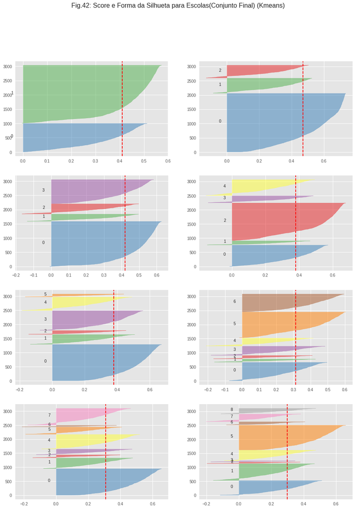

```python
cost=[]
fig, ax = plt.subplots(4, 2, figsize=(15,20))
fig.suptitle(nfig()+'Score e Forma da Silhueta para Escolas(Conjunto Final) (Kmeans)', fontsize=16)
for i in [2, 3, 4, 5, 6, 7, 8 , 9]:

    km = KMeans(n_clusters=i, max_iter=100)
    q, mod = divmod(i, 2)

    visualizer = SilhouetteVisualizer(km, colors='yellowbrick', ax=ax[q-1][mod])
    visualizer.fit(df_final)
    cost.append(km.inertia_)
```

[figure not shown]

```python
plt.plot([2, 3, 4, 5, 6, 7, 8 , 9], cost, 'bx-')
plt.xlabel('No. of clusters')
plt.ylabel('Cost')
plt.title(nfig()+'Método do Cotovelo para Escolas (Conjunto Final) (Kmodes)', fontsize=16)
plt.show()
```